# Introduction to RNAseq Analysis: Part Two

In this notebook, we will perform differential expression analysis using the count matrix we generated from part one. We will use only R codes to perform the analysis and visualization.

# Environment setting and packages

```python
%use r
# set directory
#mydir<- getwd()
#setwd(mydir)
```

```python
%use r
library(corrplot)
library(data.table)
library(edgeR, verbose=FALSE)
library(GenomicRanges, verbose=FALSE)
library(pheatmap)
library(RColorBrewer)
library(statmod, verbose=FALSE)
```

There are several popular packages or tools for DGE analysis of RNAseq data. The big three are certainly **CuffDiff2**, **DESeq2** and **edgeR**. The last two are **Bioconductor** packages. Here we will cover **edgeR** package. For a review of RNA-seq analysis workflows, see [Everaert, et al](https://www.ncbi.nlm.nih.gov/pubmed/28484260).

# Formatting the Data

## Count Matrix

We need to format our "raw" data and our "pdata". We will get the counts from the matrix that we save at the end of the previous Notebook.

```python
%use r
my_counts <- read.table("./data/rna_count_matrix.txt", row.names=1, header=TRUE)
head(my_counts)
dim(my_counts)
```

A data.frame: 6 × 8

|  | SRR3437043_Aligned.sortedByCoord.out.bam <int> | SRR3437044_Aligned.sortedByCoord.out.bam <int> | SRR3437051_Aligned.sortedByCoord.out.bam <int> | SRR3437052_Aligned.sortedByCoord.out.bam <int> | SRR3437053_Aligned.sortedByCoord.out.bam <int> | SRR3437054_Aligned.sortedByCoord.out.bam <int> | SRR3437056_Aligned.sortedByCoord.out.bam <int> | SRR3437060_Aligned.sortedByCoord.out.bam <int> |
| --- | --- | --- | --- | --- | --- | --- | --- | --- |
| 5S_rRNA | 0 | 0 | 0 | 1 | 0 | 0 | 0 | 0 |
| 5_8S_rRNA | 118 | 104 | 95 | 496 | 471 | 341 | 1952 | 613 |
| 7SK | 3 | 5 | 0 | 0 | 7 | 1 | 15 | 2 |
| A1BG | 9 | 7 | 0 | 0 | 1 | 4 | 0 | 2 |
| A1BG-AS1 | 22 | 13 | 7 | 3 | 13 | 14 | 11 | 16 |
| A1CF | 0 | 0 | 0 | 0 | 0 | 2 | 0 | 0 |

1. 39629

2. 8

The column names are the names of the BAM files. They are good file names, but they are unwieldy for coding, so we can truncate them.

```python
%use r
colnames(my_counts) <- substr(colnames(my_counts), 1, 10)
head(my_counts)
```

A data.frame: 6 × 8

|  | SRR3437043 <int> | SRR3437044 <int> | SRR3437051 <int> | SRR3437052 <int> | SRR3437053 <int> | SRR3437054 <int> | SRR3437056 <int> | SRR3437060 <int> |
| --- | --- | --- | --- | --- | --- | --- | --- | --- |
| 5S_rRNA | 0 | 0 | 0 | 1 | 0 | 0 | 0 | 0 |
| 5_8S_rRNA | 118 | 104 | 95 | 496 | 471 | 341 | 1952 | 613 |
| 7SK | 3 | 5 | 0 | 0 | 7 | 1 | 15 | 2 |
| A1BG | 9 | 7 | 0 | 0 | 1 | 4 | 0 | 2 |
| A1BG-AS1 | 22 | 13 | 7 | 3 | 13 | 14 | 11 | 16 |
| A1CF | 0 | 0 | 0 | 0 | 0 | 2 | 0 | 0 |

## Phenodata

Next, we need to get the **pdata** for the samples. We will use a file that contains the run data that we downloaded from SRA. Again, we need to do a bit of data wrangling with this information.

```python
%use r
pdata <- read.delim("./data/SraRunTable.txt", sep=",",comment.char="#", as.is=TRUE, header=TRUE)
pdata
```

A data.frame: 8 × 28

| Run <chr> | Assay.Type <chr> | AvgSpotLen <int> | BioProject <chr> | biopsy_site <chr> | BioSample <chr> | Center.Name <chr> | Consent <chr> | DATASTORE.filetype <chr> | DATASTORE.provider <chr> | ⋯ | MBytes <int> | normal.tumor <chr> | Organism <chr> | Platform <chr> | progression_step <chr> | ReleaseDate <chr> | sample_acc <chr> | Sample.Name <chr> | source_name <chr> | SRA.Study <chr> |
| --- | --- | --- | --- | --- | --- | --- | --- | --- | --- | --- | --- | --- | --- | --- | --- | --- | --- | --- | --- | --- |
| SRR3437043 | RNA-Seq | 202 | PRJNA319483 | prostate | SAMN04893323 | GEO | public | sra | ncbi | ⋯ | 1609 | nomal | Homo sapiens | ILLUMINA | BPH | 2018-04-23T00:00:00Z | SRS1410395 | GSM2131564 | BPH | SRP073789 |
| SRR3437044 | RNA-Seq | 202 | PRJNA319483 | prostate | SAMN04893324 | GEO | public | sra | gs,ncbi,s3 | ⋯ | 1519 | nomal | Homo sapiens | ILLUMINA | BPH | 2018-04-23T00:00:00Z | SRS1410393 | GSM2131565 | BPH | SRP073789 |
| SRR3437051 | RNA-Seq | 202 | PRJNA319483 | prostate | SAMN04893331 | GEO | public | sra | ncbi | ⋯ | 1748 | tumor | Homo sapiens | ILLUMINA | CaP | 2018-04-23T00:00:00Z | SRS1410400 | GSM2131572 | CaP | SRP073789 |
| SRR3437052 | RNA-Seq | 202 | PRJNA319483 | prostate | SAMN04893332 | GEO | public | sra | ncbi | ⋯ | 1974 | tumor | Homo sapiens | ILLUMINA | CaP | 2018-04-23T00:00:00Z | SRS1410402 | GSM2131573 | CaP | SRP073789 |
| SRR3437053 | RNA-Seq | 202 | PRJNA319483 | prostate | SAMN04893333 | GEO | public | sra | ncbi | ⋯ | 1607 | tumor | Homo sapiens | ILLUMINA | advanced CaP | 2018-04-23T00:00:00Z | SRS1410403 | GSM2131574 | advanced CaP | SRP073789 |
| SRR3437054 | RNA-Seq | 202 | PRJNA319483 | prostate | SAMN04893334 | GEO | public | sra | gs,ncbi,s3 | ⋯ | 1616 | tumor | Homo sapiens | ILLUMINA | CRPC | 2018-04-23T00:00:00Z | SRS1410404 | GSM2131575 | CRPC | SRP073789 |
| SRR3437056 | RNA-Seq | 202 | PRJNA319483 | prostate | SAMN04893336 | GEO | public | sra | ncbi | ⋯ | 1519 | tumor | Homo sapiens | ILLUMINA | CRPC | 2018-04-23T00:00:00Z | SRS1410406 | GSM2131577 | CRPC | SRP073789 |
| SRR3437060 | RNA-Seq | 202 | PRJNA319483 | prostate | SAMN04893340 | GEO | public | sra | ncbi | ⋯ | 1093 | tumor | Homo sapiens | ILLUMINA | advanced CaP | 2018-04-23T00:00:00Z | SRS1410410 | GSM2131581 | advanced CaP | SRP073789 |

We need a column for **group** that we will use with **edgeR**. We can extract group names based on the description column.

All the information that we need for the current analysis is in two columns.

```python
%use r
pdata <- pdata[,c("Run", "source_name")]
pdata <- pdata[order(pdata$source_name),]
pdata
```

A data.frame: 8 × 2

|  | Run <chr> | source_name <chr> |
| --- | --- | --- |
| 1 | SRR3437043 | BPH |
| 2 | SRR3437044 | BPH |
| 6 | SRR3437054 | CRPC |
| 7 | SRR3437056 | CRPC |
| 3 | SRR3437051 | CaP |
| 4 | SRR3437052 | CaP |
| 5 | SRR3437053 | advanced CaP |
| 8 | SRR3437060 | advanced CaP |

```python
%use r
colnames(pdata) <- c("run", "group")
pdata
```

A data.frame: 8 × 2

|  | run <chr> | group <chr> |
| --- | --- | --- |
| 1 | SRR3437043 | BPH |
| 2 | SRR3437044 | BPH |
| 6 | SRR3437054 | CRPC |
| 7 | SRR3437056 | CRPC |
| 3 | SRR3437051 | CaP |
| 4 | SRR3437052 | CaP |
| 5 | SRR3437053 | advanced CaP |
| 8 | SRR3437060 | advanced CaP |

The variable group needs to be converted to a **factor** for **edgeR**.

```python
%use r
pdata$group <- as.factor(pdata$group)
table(pdata$group)
```

```
         BPH         CRPC          CaP advanced CaP
           2            2            2            2
```

Confirm that "BPH" control is set as the reference level, i.e. control. **The reference level is always listed first.** In this case, we reorder the levels so BPH was set as the reference level.

```python
%use r
pdata$group <- factor(pdata$group, levels=c("BPH", "CaP", "advanced CaP", "CRPC"))
levels(pdata$group)
pdata <- pdata[order(pdata$group),]
pdata
```

1. 'BPH'

2. 'CaP'

3. 'advanced CaP'

4. 'CRPC'

A data.frame: 8 × 2

|  | run <chr> | group <fct> |
| --- | --- | --- |
| 1 | SRR3437043 | BPH |
| 2 | SRR3437044 | BPH |
| 3 | SRR3437051 | CaP |
| 4 | SRR3437052 | CaP |
| 5 | SRR3437053 | advanced CaP |
| 8 | SRR3437060 | advanced CaP |
| 6 | SRR3437054 | CRPC |
| 7 | SRR3437056 | CRPC |

A descriptive label for the individual samples in each group will be useful for plots and processed datasets.

```python
%use r
pdata$sample.label <- paste(pdata$group, 1:2, sep=".")
#pdata<-pdata[order(pdata$run),]
pdata
```

A data.frame: 8 × 3

|  | run <chr> | group <fct> | sample.label <chr> |
| --- | --- | --- | --- |
| 1 | SRR3437043 | BPH | BPH.1 |
| 2 | SRR3437044 | BPH | BPH.2 |
| 3 | SRR3437051 | CaP | CaP.1 |
| 4 | SRR3437052 | CaP | CaP.2 |
| 5 | SRR3437053 | advanced CaP | advanced CaP.1 |
| 8 | SRR3437060 | advanced CaP | advanced CaP.2 |
| 6 | SRR3437054 | CRPC | CRPC.1 |
| 7 | SRR3437056 | CRPC | CRPC.2 |

Now, we are ready to send the data to **edgeR**. The basic object class for edgeR is a **DGEList**. You need a gene count matrix and group assignments.

# Statistical Analysis using edgeR

## Making the DGEList

Now we are ready to start the **edgeR** analysis. The first step is to format the count data and phenodata as a **DGEList** object.

```python
%use r
# first, reorder counts matrix to match with phenodata
my_counts<-my_counts[,pdata$run]
head(my_counts)
```

A data.frame: 6 × 8

|  | SRR3437043 <int> | SRR3437044 <int> | SRR3437051 <int> | SRR3437052 <int> | SRR3437053 <int> | SRR3437060 <int> | SRR3437054 <int> | SRR3437056 <int> |
| --- | --- | --- | --- | --- | --- | --- | --- | --- |
| 5S_rRNA | 0 | 0 | 0 | 1 | 0 | 0 | 0 | 0 |
| 5_8S_rRNA | 118 | 104 | 95 | 496 | 471 | 613 | 341 | 1952 |
| 7SK | 3 | 5 | 0 | 0 | 7 | 2 | 1 | 15 |
| A1BG | 9 | 7 | 0 | 0 | 1 | 2 | 4 | 0 |
| A1BG-AS1 | 22 | 13 | 7 | 3 | 13 | 16 | 14 | 11 |
| A1CF | 0 | 0 | 0 | 0 | 0 | 0 | 2 | 0 |

```python
%use r
## make DGE object
my_dge <- DGEList(counts = my_counts, group = pdata$group)
my_dge$samples$sample.label <- pdata$sample.label
head(my_dge)
```

**$counts**

A matrix: 6 × 8 of type int

|  | SRR3437043 | SRR3437044 | SRR3437051 | SRR3437052 | SRR3437053 | SRR3437060 | SRR3437054 | SRR3437056 |
| --- | --- | --- | --- | --- | --- | --- | --- | --- |
| 5S_rRNA | 0 | 0 | 0 | 1 | 0 | 0 | 0 | 0 |
| 5_8S_rRNA | 118 | 104 | 95 | 496 | 471 | 613 | 341 | 1952 |
| 7SK | 3 | 5 | 0 | 0 | 7 | 2 | 1 | 15 |
| A1BG | 9 | 7 | 0 | 0 | 1 | 2 | 4 | 0 |
| A1BG-AS1 | 22 | 13 | 7 | 3 | 13 | 16 | 14 | 11 |
| A1CF | 0 | 0 | 0 | 0 | 0 | 0 | 2 | 0 |

**$samples**

A data.frame: 8 × 4

|  | group <fct> | lib.size <dbl> | norm.factors <dbl> | sample.label <chr> |
| --- | --- | --- | --- | --- |
| SRR3437043 | BPH | 2864937 | 1 | BPH.1 |
| SRR3437044 | BPH | 2734942 | 1 | BPH.2 |
| SRR3437051 | CaP | 2200120 | 1 | CaP.1 |
| SRR3437052 | CaP | 2546312 | 1 | CaP.2 |
| SRR3437053 | advanced CaP | 3645018 | 1 | advanced CaP.1 |
| SRR3437060 | advanced CaP | 2170188 | 1 | advanced CaP.2 |
| SRR3437054 | CRPC | 3520742 | 1 | CRPC.1 |
| SRR3437056 | CRPC | 5619008 | 1 | CRPC.2 |

## Filtering the Data

We need to remove genes that are not expressed at a certain threshold. Where you set this threshold is a matter of debate. Certainly genes with no counts in any sample should be removed.

```python
%use r
all_zeroes <- apply(my_dge$counts, 1, sum) == 0
table(all_zeroes)
```

```
all_zeroes
FALSE  TRUE
24900 14729
```

This shows that there are 14,729 genes that do not appear to be expressed in any sample. If you wanted to be very conservative, this would be an acceptable filter, i.e. simply drop all the genes with no counts. Generally, a less conservative strategy is recommended that takes into account the library size. To do this, we need to convert the raw counts to Counts Per Million (cpm). There is an **edgeR** function for this.

```python
%use r
my_cpm <- cpm(my_dge, normalized.lib.size=FALSE, log=FALSE)
head(my_cpm)
```

A matrix: 6 × 8 of type dbl

|  | SRR3437043 | SRR3437044 | SRR3437051 | SRR3437052 | SRR3437053 | SRR3437060 | SRR3437054 | SRR3437056 |
| --- | --- | --- | --- | --- | --- | --- | --- | --- |
| 5S_rRNA | 0.000000 | 0.000000 | 0.000000 | 0.3927249 | 0.0000000 | 0.0000000 | 0.0000000 | 0.000000 |
| 5_8S_rRNA | 41.187642 | 38.026401 | 43.179463 | 194.7915259 | 129.2174689 | 282.4640077 | 96.8545835 | 347.392280 |
| 7SK | 1.047143 | 1.828192 | 0.000000 | 0.0000000 | 1.9204295 | 0.9215791 | 0.2840310 | 2.669510 |
| A1BG | 3.141430 | 2.559469 | 0.000000 | 0.0000000 | 0.2743471 | 0.9215791 | 1.1361241 | 0.000000 |
| A1BG-AS1 | 7.679052 | 4.753300 | 3.181645 | 1.1781746 | 3.5665119 | 7.3726332 | 3.9764345 | 1.957641 |
| A1CF | 0.000000 | 0.000000 | 0.000000 | 0.0000000 | 0.0000000 | 0.0000000 | 0.5680621 | 0.000000 |

There is still the question of what CPM threshold to use for expression. I have seen values from 0.1 to 10 used. I think that both are extreme, and I typically use 1. With that, we can convert the CPM matrix to a **logical** matrix that shows whether the CPM is greater than 1 or not.

```python
%use r
expressed <- apply(my_cpm, 2, function(x)(x >= 1))
expressed[1:10, ]
```

A matrix: 10 × 8 of type lgl

|  | SRR3437043 | SRR3437044 | SRR3437051 | SRR3437052 | SRR3437053 | SRR3437060 | SRR3437054 | SRR3437056 |
| --- | --- | --- | --- | --- | --- | --- | --- | --- |
| 5S_rRNA | FALSE | FALSE | FALSE | FALSE | FALSE | FALSE | FALSE | FALSE |
| 5_8S_rRNA | TRUE | TRUE | TRUE | TRUE | TRUE | TRUE | TRUE | TRUE |
| 7SK | TRUE | TRUE | FALSE | FALSE | TRUE | FALSE | FALSE | TRUE |
| A1BG | TRUE | TRUE | FALSE | FALSE | FALSE | FALSE | TRUE | FALSE |
| A1BG-AS1 | TRUE | TRUE | TRUE | TRUE | TRUE | TRUE | TRUE | TRUE |
| A1CF | FALSE | FALSE | FALSE | FALSE | FALSE | FALSE | FALSE | FALSE |
| A2M | TRUE | TRUE | TRUE | TRUE | TRUE | TRUE | TRUE | TRUE |
| A2M-AS1 | TRUE | TRUE | TRUE | TRUE | TRUE | TRUE | TRUE | TRUE |
| A2ML1 | TRUE | TRUE | FALSE | FALSE | FALSE | TRUE | TRUE | FALSE |
| A2ML1-AS1 | FALSE | FALSE | FALSE | FALSE | FALSE | FALSE | FALSE | FALSE |

Again, we have another cutoff choice. Does a gene need to be expressed in only one sample or multiple samples to be retained? We could use the logic that a gene might be expressed under only one biological condition (group). Therefore, we set the cutoff to 2, i.e. the number of biological replicates in each group.

```python
%use r
keep <- apply(expressed, 1, sum) >= 2
table(keep)
```

```
keep
FALSE  TRUE
21623 18006
```

So, we are going to discard about half of our features due to low or no expression. Note, some packages such as **DESeq2** and **edgeR** optimize this parameter for you, which usually filters out genes with less than 10 counts.

Now, we can recreate the **DGEList**, filtering the count matrix to remove unexpressed genes.

```python
%use r
my_dge <- DGEList(counts = my_counts[keep, ], group = pdata$group)
my_dge$samples$sample.label <- pdata$sample.label
my_dge <- calcNormFactors(my_dge, method="TMM")
my_dge
```

**$counts**

A matrix: 18006 × 8 of type int

|  | SRR3437043 | SRR3437044 | SRR3437051 | SRR3437052 | SRR3437053 | SRR3437060 | SRR3437054 | SRR3437056 |
| --- | --- | --- | --- | --- | --- | --- | --- | --- |
| 5_8S_rRNA | 118 | 104 | 95 | 496 | 471 | 613 | 341 | 1952 |
| 7SK | 3 | 5 | 0 | 0 | 7 | 2 | 1 | 15 |
| A1BG | 9 | 7 | 0 | 0 | 1 | 2 | 4 | 0 |
| A1BG-AS1 | 22 | 13 | 7 | 3 | 13 | 16 | 14 | 11 |
| A2M | 4707 | 5621 | 811 | 507 | 813 | 507 | 678 | 3520 |
| A2M-AS1 | 903 | 923 | 86 | 122 | 401 | 173 | 246 | 1446 |
| A2ML1 | 4 | 3 | 0 | 0 | 1 | 4 | 8 | 5 |
| A2MP1 | 4 | 14 | 2 | 0 | 1 | 0 | 3 | 1 |
| A4GALT | 99 | 56 | 47 | 38 | 14 | 28 | 19 | 46 |
| AAAS | 150 | 143 | 94 | 133 | 134 | 152 | 289 | 131 |
| AACS | 57 | 50 | 52 | 133 | 98 | 63 | 189 | 103 |
| AADAT | 41 | 58 | 61 | 199 | 194 | 223 | 387 | 132 |
| AAGAB | 71 | 71 | 111 | 111 | 97 | 104 | 162 | 109 |
| AAK1 | 87 | 116 | 117 | 113 | 299 | 114 | 450 | 117 |
| AAMDC | 64 | 39 | 26 | 49 | 25 | 30 | 28 | 107 |
| AAMP | 238 | 226 | 238 | 337 | 220 | 306 | 509 | 293 |
| AAR2 | 109 | 88 | 40 | 90 | 49 | 59 | 94 | 91 |
| AARS1 | 305 | 243 | 141 | 244 | 254 | 383 | 511 | 342 |
| AARS2 | 71 | 66 | 86 | 68 | 72 | 76 | 112 | 51 |
| AARSD1 | 34 | 44 | 58 | 57 | 41 | 52 | 61 | 54 |
| AASDH | 17 | 45 | 27 | 30 | 11 | 26 | 45 | 25 |
| AASDHPPT | 38 | 44 | 57 | 58 | 30 | 33 | 55 | 48 |
| AASS | 101 | 154 | 77 | 90 | 59 | 46 | 60 | 91 |
| AATBC | 13 | 11 | 0 | 1 | 0 | 1 | 0 | 0 |
| AATF | 98 | 69 | 91 | 75 | 69 | 37 | 103 | 116 |
| AATK | 91 | 52 | 117 | 235 | 134 | 120 | 212 | 180 |
| ABALON | 57 | 52 | 80 | 46 | 18 | 32 | 42 | 39 |
| ABAT | 133 | 157 | 209 | 370 | 118 | 69 | 126 | 183 |
| ABCA1 | 32 | 59 | 26 | 30 | 11 | 11 | 15 | 46 |
| ABCA10 | 9 | 14 | 3 | 9 | 9 | 7 | 13 | 11 |
| ⋮ | ⋮ | ⋮ | ⋮ | ⋮ | ⋮ | ⋮ | ⋮ | ⋮ |
| ZSCAN5A | 14 | 17 | 5 | 15 | 13 | 11 | 16 | 16 |
| ZSCAN5A-AS1 | 2 | 1 | 2 | 2 | 4 | 4 | 5 | 3 |
| ZSCAN9 | 30 | 33 | 27 | 26 | 38 | 43 | 51 | 60 |
| ZSWIM1 | 39 | 28 | 19 | 22 | 26 | 32 | 48 | 31 |
| ZSWIM3 | 20 | 4 | 5 | 15 | 11 | 19 | 19 | 7 |
| ZSWIM4 | 16 | 23 | 30 | 23 | 18 | 15 | 20 | 29 |
| ZSWIM5 | 36 | 34 | 31 | 18 | 14 | 23 | 28 | 15 |
| ZSWIM5P2 | 5 | 3 | 3 | 1 | 0 | 0 | 1 | 0 |
| ZSWIM6 | 44 | 62 | 57 | 16 | 32 | 22 | 42 | 39 |
| ZSWIM7 | 56 | 47 | 34 | 62 | 54 | 28 | 77 | 86 |
| ZSWIM8 | 353 | 393 | 338 | 255 | 277 | 406 | 427 | 304 |
| ZSWIM8-AS1 | 21 | 15 | 22 | 11 | 18 | 19 | 28 | 21 |
| ZSWIM9 | 29 | 23 | 17 | 24 | 13 | 17 | 39 | 36 |
| ZUP1 | 12 | 19 | 15 | 20 | 14 | 23 | 20 | 35 |
| ZW10 | 33 | 31 | 19 | 30 | 10 | 30 | 18 | 34 |
| ZWILCH | 7 | 20 | 20 | 23 | 26 | 18 | 17 | 32 |
| ZWINT | 18 | 27 | 25 | 29 | 12 | 60 | 73 | 44 |
| ZXDA | 8 | 16 | 13 | 8 | 0 | 4 | 18 | 9 |
| ZXDB | 36 | 26 | 29 | 23 | 12 | 14 | 38 | 32 |
| ZXDC | 75 | 117 | 75 | 81 | 115 | 117 | 251 | 89 |
| ZYG11A | 4 | 3 | 5 | 11 | 17 | 38 | 21 | 18 |
| ZYG11B | 72 | 62 | 50 | 66 | 38 | 29 | 55 | 62 |
| ZYX | 575 | 279 | 209 | 212 | 188 | 111 | 310 | 162 |
| ZZEF1 | 208 | 189 | 228 | 126 | 123 | 79 | 183 | 148 |
| ZZZ3 | 60 | 76 | 62 | 59 | 47 | 61 | 59 | 98 |
| ensembl | 708 | 608 | 479 | 577 | 350 | 361 | 767 | 750 |
| ensembl_havana | 3383 | 3665 | 3233 | 2929 | 2346 | 2829 | 3759 | 3659 |
| havana | 98209 | 91424 | 76479 | 89276 | 92192 | 74319 | 109766 | 157320 |
| havana_tagene | 4775 | 4514 | 4764 | 5591 | 4581 | 4756 | 7189 | 6482 |
| mirbase | 163 | 151 | 44 | 111 | 396 | 46 | 180 | 465 |

**$samples**

A data.frame: 8 × 4

|  | group <fct> | lib.size <dbl> | norm.factors <dbl> | sample.label <chr> |
| --- | --- | --- | --- | --- |
| SRR3437043 | BPH | 2860557 | 1.1155064 | BPH.1 |
| SRR3437044 | BPH | 2730626 | 1.1789008 | BPH.2 |
| SRR3437051 | CaP | 2196625 | 1.2625961 | CaP.1 |
| SRR3437052 | CaP | 2542831 | 1.1480381 | CaP.2 |
| SRR3437053 | advanced CaP | 3642389 | 0.6749855 | advanced CaP.1 |
| SRR3437060 | advanced CaP | 2167746 | 1.1832255 | advanced CaP.2 |
| SRR3437054 | CRPC | 3515456 | 1.0691828 | CRPC.1 |
| SRR3437056 | CRPC | 5609871 | 0.6143502 | CRPC.2 |

## Normalizing the Libraries

A **HUGE** issue with any NGS experiment is normalization. Rarely do you get back the same number of reads for each library. If you do, often you will get different alignment efficiencies that will affect the gene count matrix.

This is one parameter that I typically leave the defaults. The TMM method can account for over-representation of specific genes in one library over another. For example, if rRNA is abundant in a particular sample, not only will the rRNA levels be high, but other genes may be under-sequenced because the rRNA sequences consumed the sequencing resource. For more information, see [Robinson and Oshlack](https://www.ncbi.nlm.nih.gov/pmc/articles/PMC2864565/).

**edgeR** does provide alternative normalization methods. In addition, it is possible to normalize your count matrix with other software before you convert it to a **DGEList**.

```python
%use r
my_dge <- calcNormFactors(my_dge, method="TMM")
my_dge
```

**$counts**

A matrix: 18006 × 8 of type int

|  | SRR3437043 | SRR3437044 | SRR3437051 | SRR3437052 | SRR3437053 | SRR3437060 | SRR3437054 | SRR3437056 |
| --- | --- | --- | --- | --- | --- | --- | --- | --- |
| 5_8S_rRNA | 118 | 104 | 95 | 496 | 471 | 613 | 341 | 1952 |
| 7SK | 3 | 5 | 0 | 0 | 7 | 2 | 1 | 15 |
| A1BG | 9 | 7 | 0 | 0 | 1 | 2 | 4 | 0 |
| A1BG-AS1 | 22 | 13 | 7 | 3 | 13 | 16 | 14 | 11 |
| A2M | 4707 | 5621 | 811 | 507 | 813 | 507 | 678 | 3520 |
| A2M-AS1 | 903 | 923 | 86 | 122 | 401 | 173 | 246 | 1446 |
| A2ML1 | 4 | 3 | 0 | 0 | 1 | 4 | 8 | 5 |
| A2MP1 | 4 | 14 | 2 | 0 | 1 | 0 | 3 | 1 |
| A4GALT | 99 | 56 | 47 | 38 | 14 | 28 | 19 | 46 |
| AAAS | 150 | 143 | 94 | 133 | 134 | 152 | 289 | 131 |
| AACS | 57 | 50 | 52 | 133 | 98 | 63 | 189 | 103 |
| AADAT | 41 | 58 | 61 | 199 | 194 | 223 | 387 | 132 |
| AAGAB | 71 | 71 | 111 | 111 | 97 | 104 | 162 | 109 |
| AAK1 | 87 | 116 | 117 | 113 | 299 | 114 | 450 | 117 |
| AAMDC | 64 | 39 | 26 | 49 | 25 | 30 | 28 | 107 |
| AAMP | 238 | 226 | 238 | 337 | 220 | 306 | 509 | 293 |
| AAR2 | 109 | 88 | 40 | 90 | 49 | 59 | 94 | 91 |
| AARS1 | 305 | 243 | 141 | 244 | 254 | 383 | 511 | 342 |
| AARS2 | 71 | 66 | 86 | 68 | 72 | 76 | 112 | 51 |
| AARSD1 | 34 | 44 | 58 | 57 | 41 | 52 | 61 | 54 |
| AASDH | 17 | 45 | 27 | 30 | 11 | 26 | 45 | 25 |
| AASDHPPT | 38 | 44 | 57 | 58 | 30 | 33 | 55 | 48 |
| AASS | 101 | 154 | 77 | 90 | 59 | 46 | 60 | 91 |
| AATBC | 13 | 11 | 0 | 1 | 0 | 1 | 0 | 0 |
| AATF | 98 | 69 | 91 | 75 | 69 | 37 | 103 | 116 |
| AATK | 91 | 52 | 117 | 235 | 134 | 120 | 212 | 180 |
| ABALON | 57 | 52 | 80 | 46 | 18 | 32 | 42 | 39 |
| ABAT | 133 | 157 | 209 | 370 | 118 | 69 | 126 | 183 |
| ABCA1 | 32 | 59 | 26 | 30 | 11 | 11 | 15 | 46 |
| ABCA10 | 9 | 14 | 3 | 9 | 9 | 7 | 13 | 11 |
| ⋮ | ⋮ | ⋮ | ⋮ | ⋮ | ⋮ | ⋮ | ⋮ | ⋮ |
| ZSCAN5A | 14 | 17 | 5 | 15 | 13 | 11 | 16 | 16 |
| ZSCAN5A-AS1 | 2 | 1 | 2 | 2 | 4 | 4 | 5 | 3 |
| ZSCAN9 | 30 | 33 | 27 | 26 | 38 | 43 | 51 | 60 |
| ZSWIM1 | 39 | 28 | 19 | 22 | 26 | 32 | 48 | 31 |
| ZSWIM3 | 20 | 4 | 5 | 15 | 11 | 19 | 19 | 7 |
| ZSWIM4 | 16 | 23 | 30 | 23 | 18 | 15 | 20 | 29 |
| ZSWIM5 | 36 | 34 | 31 | 18 | 14 | 23 | 28 | 15 |
| ZSWIM5P2 | 5 | 3 | 3 | 1 | 0 | 0 | 1 | 0 |
| ZSWIM6 | 44 | 62 | 57 | 16 | 32 | 22 | 42 | 39 |
| ZSWIM7 | 56 | 47 | 34 | 62 | 54 | 28 | 77 | 86 |
| ZSWIM8 | 353 | 393 | 338 | 255 | 277 | 406 | 427 | 304 |
| ZSWIM8-AS1 | 21 | 15 | 22 | 11 | 18 | 19 | 28 | 21 |
| ZSWIM9 | 29 | 23 | 17 | 24 | 13 | 17 | 39 | 36 |
| ZUP1 | 12 | 19 | 15 | 20 | 14 | 23 | 20 | 35 |
| ZW10 | 33 | 31 | 19 | 30 | 10 | 30 | 18 | 34 |
| ZWILCH | 7 | 20 | 20 | 23 | 26 | 18 | 17 | 32 |
| ZWINT | 18 | 27 | 25 | 29 | 12 | 60 | 73 | 44 |
| ZXDA | 8 | 16 | 13 | 8 | 0 | 4 | 18 | 9 |
| ZXDB | 36 | 26 | 29 | 23 | 12 | 14 | 38 | 32 |
| ZXDC | 75 | 117 | 75 | 81 | 115 | 117 | 251 | 89 |
| ZYG11A | 4 | 3 | 5 | 11 | 17 | 38 | 21 | 18 |
| ZYG11B | 72 | 62 | 50 | 66 | 38 | 29 | 55 | 62 |
| ZYX | 575 | 279 | 209 | 212 | 188 | 111 | 310 | 162 |
| ZZEF1 | 208 | 189 | 228 | 126 | 123 | 79 | 183 | 148 |
| ZZZ3 | 60 | 76 | 62 | 59 | 47 | 61 | 59 | 98 |
| ensembl | 708 | 608 | 479 | 577 | 350 | 361 | 767 | 750 |
| ensembl_havana | 3383 | 3665 | 3233 | 2929 | 2346 | 2829 | 3759 | 3659 |
| havana | 98209 | 91424 | 76479 | 89276 | 92192 | 74319 | 109766 | 157320 |
| havana_tagene | 4775 | 4514 | 4764 | 5591 | 4581 | 4756 | 7189 | 6482 |
| mirbase | 163 | 151 | 44 | 111 | 396 | 46 | 180 | 465 |

**$samples**

A data.frame: 8 × 4

|  | group <fct> | lib.size <dbl> | norm.factors <dbl> | sample.label <chr> |
| --- | --- | --- | --- | --- |
| SRR3437043 | BPH | 2860557 | 1.1155064 | BPH.1 |
| SRR3437044 | BPH | 2730626 | 1.1789008 | BPH.2 |
| SRR3437051 | CaP | 2196625 | 1.2625961 | CaP.1 |
| SRR3437052 | CaP | 2542831 | 1.1480381 | CaP.2 |
| SRR3437053 | advanced CaP | 3642389 | 0.6749855 | advanced CaP.1 |
| SRR3437060 | advanced CaP | 2167746 | 1.1832255 | advanced CaP.2 |
| SRR3437054 | CRPC | 3515456 | 1.0691828 | CRPC.1 |
| SRR3437056 | CRPC | 5609871 | 0.6143502 | CRPC.2 |

If you scroll down to the samples data, you will see that a column named **norm.factors** has been added. If you compare the **norm.factors** to the **lib.size**, you should see that the normalization is not a simple scaling factor based only on the size of the libraries.

### Counts Per Million

It is always a good idea to visualize your data before you proceed. First, we need to make the CPM matrix again. We will do it both for raw and normalized counts.

```python
%use r
cpm_raw <- cpm(my_dge, normalized.lib.size=FALSE, log=FALSE)
cpm_norm <- cpm(my_dge, normalized.lib.size=TRUE, log=FALSE)
```

```python
%use r
head(cpm_raw)
```

A matrix: 6 × 8 of type dbl

|  | SRR3437043 | SRR3437044 | SRR3437051 | SRR3437052 | SRR3437053 | SRR3437060 | SRR3437054 | SRR3437056 |
| --- | --- | --- | --- | --- | --- | --- | --- | --- |
| 5_8S_rRNA | 41.250707 | 38.086505 | 43.248165 | 195.058185 | 129.3107353 | 282.7822079 | 97.0002185 | 347.958090 |
| 7SK | 1.048747 | 1.831082 | 0.000000 | 0.000000 | 1.9218156 | 0.9226173 | 0.2844581 | 2.673858 |
| A1BG | 3.146240 | 2.563515 | 0.000000 | 0.000000 | 0.2745451 | 0.9226173 | 1.1378325 | 0.000000 |
| A1BG-AS1 | 7.690810 | 4.760813 | 3.186707 | 1.179787 | 3.5690861 | 7.3809385 | 3.9824137 | 1.960829 |
| A2M | 1645.483729 | 2058.502336 | 369.202754 | 199.384072 | 223.2051546 | 233.8834900 | 192.8626045 | 627.465409 |
| A2M-AS1 | 315.672787 | 338.017729 | 39.150970 | 47.978021 | 110.0925793 | 79.8063980 | 69.9766972 | 257.759938 |

```python
%use r
head(cpm_norm)
```

A matrix: 6 × 8 of type dbl

|  | SRR3437043 | SRR3437044 | SRR3437051 | SRR3437052 | SRR3437053 | SRR3437060 | SRR3437054 | SRR3437056 |
| --- | --- | --- | --- | --- | --- | --- | --- | --- |
| 5_8S_rRNA | 36.9793562 | 32.306793 | 34.253365 | 169.905675 | 191.5755823 | 238.9926577 | 90.7236986 | 566.383905 |
| 7SK | 0.9401531 | 1.553211 | 0.000000 | 0.000000 | 2.8471955 | 0.7797477 | 0.2660519 | 4.352335 |
| A1BG | 2.8204594 | 2.174496 | 0.000000 | 0.000000 | 0.4067422 | 0.7797477 | 1.0642076 | 0.000000 |
| A1BG-AS1 | 6.8944562 | 4.038349 | 2.523932 | 1.027655 | 5.2876488 | 6.2379813 | 3.7247266 | 3.191713 |
| A2M | 1475.1002521 | 1746.120056 | 292.415570 | 173.673745 | 330.6814191 | 197.6660318 | 180.3831897 | 1021.348026 |
| A2M-AS1 | 282.9860904 | 286.722792 | 31.008310 | 41.791315 | 163.1036274 | 67.4481726 | 65.4487679 | 419.565127 |

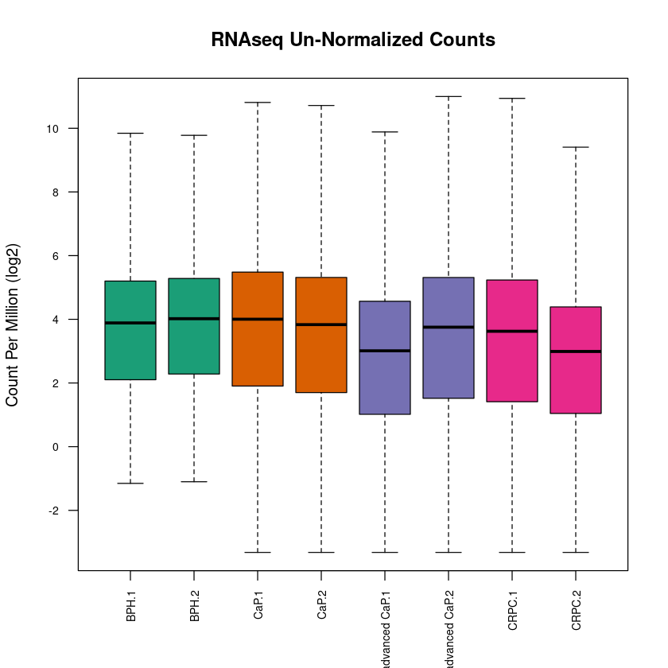

```python
%use r
#library(RColorBrewer)
group_pal <- brewer.pal(4, "Dark2")
group_cols <- group_pal[my_dge$samples$group]
boxplot(log2(cpm_raw + 0.1), col=group_cols, las=2, outline=FALSE, names=pdata$sample.label, cex.axis=0.7,
        main="RNAseq Un-Normalized Counts", ylab="Count Per Million (log2)")
```

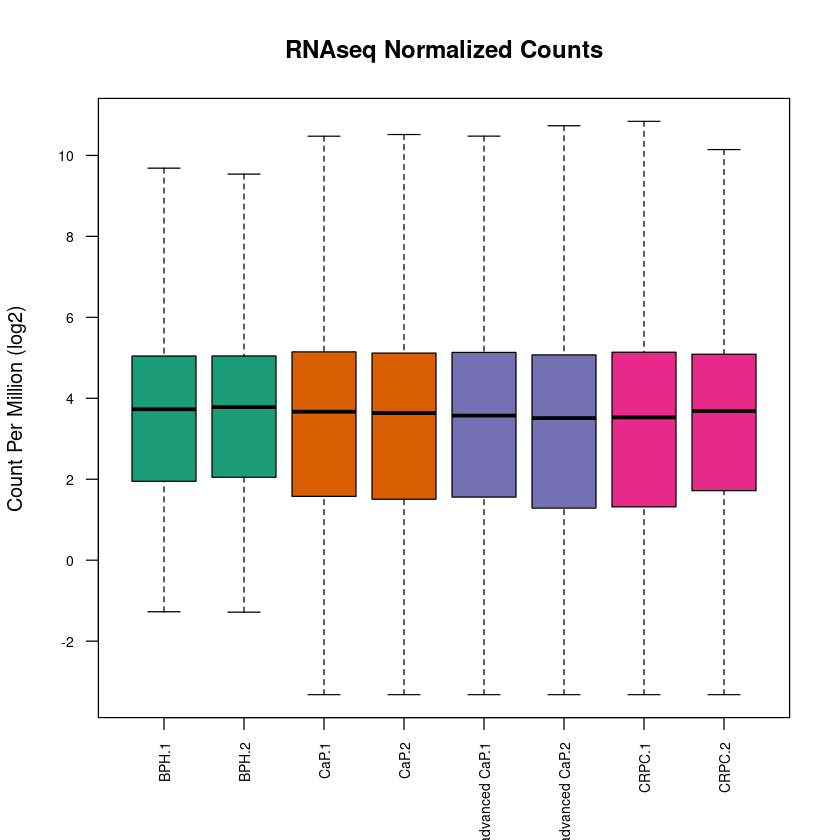

```python
%use r
boxplot(log2(cpm_norm + 0.1), col=group_cols, las=2, outline=FALSE, names=pdata$sample.label, cex.axis=0.7,
        main="RNAseq Normalized Counts", ylab="Count Per Million (log2)")
```

Despite the differences in the overall size of the libraries, they appear similar after normalization.

The CPM values are a useful way to visualize RNA-seq data, but they do not account for the length of the transcripts. This is one shortfall of RNA-seq over microarrays. Expression of short genes is always at a disadvantage to expression of long genes because there is simply less RNA to sequence. This is especially true if your RNA-seq analysis pipeline removes duplicate sequences.

One thing that you can do is scale the CPM values accounting for the length of the genes. Note, this IS NOT done for the actual differential expression analysis in **edgeR**. It can be done to aid visualization and downstream functional analysis.

### Reads Per Kilobase Per Million

RPKM values can be used to compare relative expression levels of different genes. Again, not generally on a statistical basis, but more for functional analysis. To convert the CPM values to RPKM (Reads Per Kilobase Per Million), we need the length of the synthetic transcripts. We can get this from the **GRangesList** that we made.

```python
%use r
#library(GenomicRanges, verbose=FALSE)
load("./data/GenesByExons.RData")
```

First, we use **width** to get the length of each exon.

```python
%use r
exon_lengths <- width(genesByExon_gr)
head(exon_lengths)
```

```
IntegerList of length 6
[["5S_rRNA"]] 126 110 119 106 119 119 115 87 120 119
[["5_8S_rRNA"]] 151 152 152 152 151 153 152 153 153
[["7SK"]] 250 250 250 244 331 298 247
[["A1BG"]] 1852 305 282 1165 270 36 89
[["A1BG-AS1"]] 127 1505 1742
[["A1CF"]] 7472 149 137 206 274 98 165 74 239 131 135 143 144 93 48 95
```

Now, we can **sum** the length of the exons for each transcript using **sapply** to work down the list.

```python
%use r
transcript_lengths <- sapply(exon_lengths, sum)
head(transcript_lengths)
```

**5S_rRNA**

1140

**5_8S_rRNA**

1369

**7SK**

1870

**A1BG**

3999

**A1BG-AS1**

3374

**A1CF**

9603

Now, we need to remove the same transcripts that we filtered from the **DGEList**.

```python
%use r
lengths_keep <- transcript_lengths[keep]
head(lengths_keep)
```

**5_8S_rRNA**

1369

**7SK**

1870

**A1BG**

3999

**A1BG-AS1**

3374

**A2M**

6318

**A2M-AS1**

2948

We can confirm that the dimension and order of the transcript lengths is the same as the order of the transcripts in **cpm_norm**.

```python
%use r
lengths_keep<-lengths_keep[names(lengths_keep) %in% rownames(my_dge$counts)]
length(lengths_keep)
dim(my_dge)
```

18006

1. 18006

2. 8

```python
%use r
table(names(lengths_keep) == rownames(my_dge$counts))
head(names(lengths_keep)) # print first 6 names
head(rownames(my_dge$counts))
```

```
 TRUE
18006
```

1. '5_8S_rRNA'

2. '7SK'

3. 'A1BG'

4. 'A1BG-AS1'

5. 'A2M'

6. 'A2M-AS1'

1. '5_8S_rRNA'

2. '7SK'

3. 'A1BG'

4. 'A1BG-AS1'

5. 'A2M'

6. 'A2M-AS1'

```python
%use r
rpkm_norm <- rpkm(my_dge, gene.length=lengths_keep, normalized.lib.sizes=TRUE, log=FALSE)
head(rpkm_norm)
```

A matrix: 6 × 8 of type dbl

|  | SRR3437043 | SRR3437044 | SRR3437051 | SRR3437052 | SRR3437053 | SRR3437060 | SRR3437054 | SRR3437056 |
| --- | --- | --- | --- | --- | --- | --- | --- | --- |
| 5_8S_rRNA | 27.0119476 | 23.5988265 | 25.0207196 | 124.1093319 | 139.938336 | 174.5746221 | 66.2700501 | 413.7208951 |
| 7SK | 0.5027557 | 0.8305942 | 0.0000000 | 0.0000000 | 1.522564 | 0.4169774 | 0.1422737 | 2.3274521 |
| A1BG | 0.7052912 | 0.5437599 | 0.0000000 | 0.0000000 | 0.101711 | 0.1949857 | 0.2661184 | 0.0000000 |
| A1BG-AS1 | 2.0434073 | 1.1969025 | 0.7480534 | 0.3045807 | 1.567175 | 1.8488386 | 1.1039498 | 0.9459729 |
| A2M | 233.4758234 | 276.3722786 | 46.2829329 | 27.4887219 | 52.339573 | 31.2861715 | 28.5506790 | 161.6568576 |
| A2M-AS1 | 95.9925680 | 97.2601057 | 10.5184225 | 14.1761585 | 55.326875 | 22.8792987 | 22.2010746 | 142.3219561 |

We are now ready to start the **edgeR** analysis.

## Making the Model Matrix

The next step in the analysis is to describe the experiment and analysis for **edgeR** in the form of a matrix. The matrix must have one row for every sample and one column for each of the experimental effects/groups that you want to compare.

What experimental effects should we compare? For this data, we have one control (BPH) and three treatment groups (CaP, advanced CaP and CRPC). We could specify a design to estimate each group's effect separately (as well as any interaction). This will allow us to specify pairwise contrasts later.

The `model.matrix` function makes this quite simple because it can pull the information from the pData. However, it is always a good idea to check your matrix.

```python
%use r
my_design <- model.matrix(~ 0 + my_dge$samples$group)
rownames(my_design) <- rownames(my_dge$sample)
colnames(my_design) <- levels(my_dge$sample$group)
my_design
```

A matrix: 8 × 4 of type dbl

|  | BPH | CaP | advanced CaP | CRPC |
| --- | --- | --- | --- | --- |
| SRR3437043 | 1 | 0 | 0 | 0 |
| SRR3437044 | 1 | 0 | 0 | 0 |
| SRR3437051 | 0 | 1 | 0 | 0 |
| SRR3437052 | 0 | 1 | 0 | 0 |
| SRR3437053 | 0 | 0 | 1 | 0 |
| SRR3437060 | 0 | 0 | 1 | 0 |
| SRR3437054 | 0 | 0 | 0 | 1 |
| SRR3437056 | 0 | 0 | 0 | 1 |

We are finally getting to the statistical analysis.

RNA-seq data is based on counts and is discrete (integer values only). Because of the nature of the data, edgeR uses **exactTest** function to perform a test that is based on the negative binomial distribution. Earlier methods of RNAseq analysis used the Poisson distribution, but these methods have fallen out of favor because the Poisson distribution is not a good fit for RNAseq data.

## Estimate Dispersion

First, we need to estimate the dispersion in the gene counts. The disperion is the variability in the data, sometimes from biological sources, but technical factors can also affect disperion. Note that **edgeR** allows you to set a minimal expression threshold for the genes. We have already filtered our data, so I set this to zero.

```python
%use r
#library(statmod, verbose=FALSE)
my_dge <- estimateDisp(my_dge, design=my_design, min.row.sum=0, robust=TRUE)
```

Now, we can plot the dispersion. Three values are shown:

- **Tagwise** - The actual dispresion of each individual gene.
- **Common** - The estimate for all genes.
- **Trended** - Takes into account the value of the counts, i.e. low expressing gene often have high disperion.

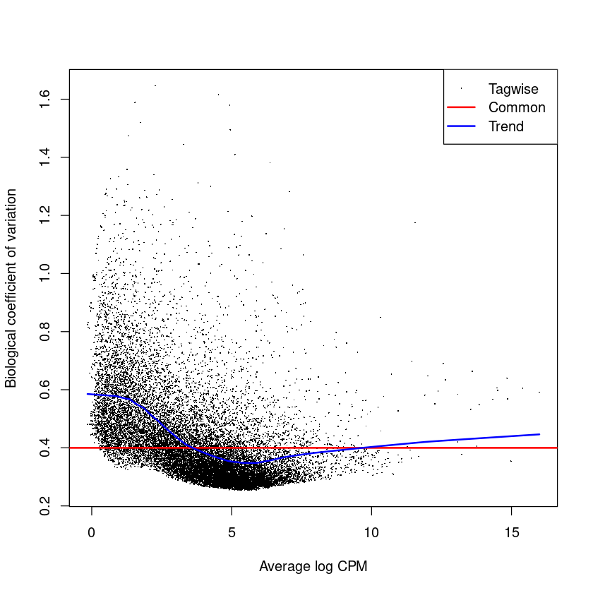

```python
%use r
plotBCV(my_dge)
```

### MDS Plots to Assess Replicates

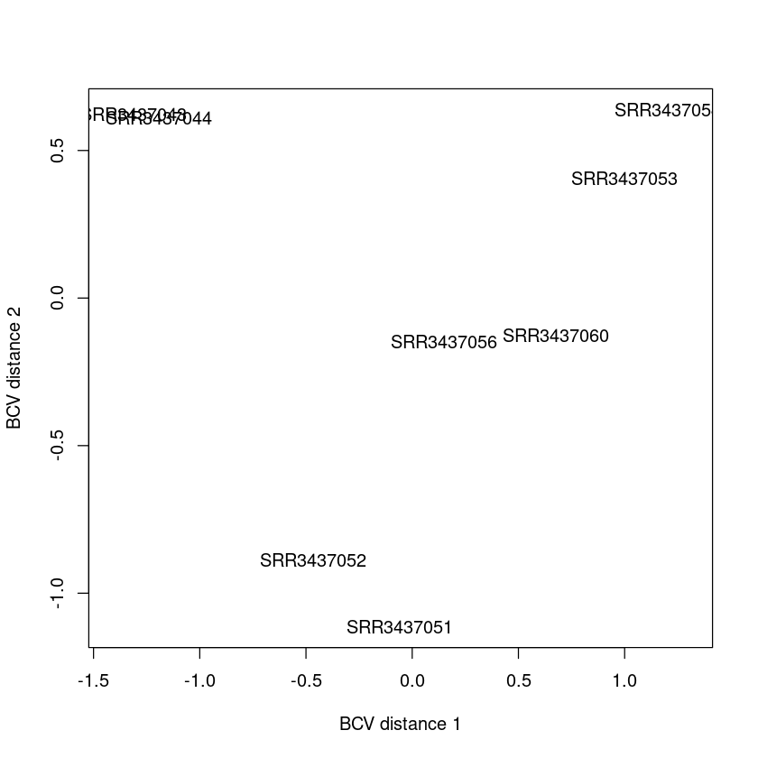

```python
%use r
plotMDS(my_dge, method="bcv", top=500)
```

We can add group labels and color the samples by group.

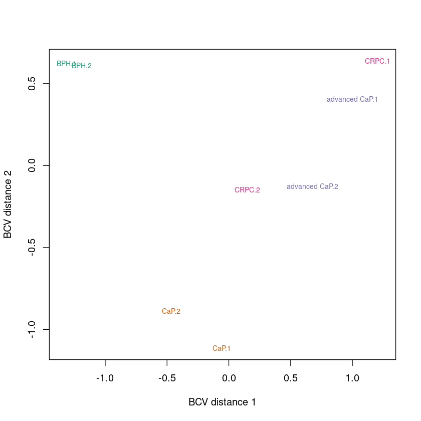

```python
%use r
plotMDS(my_dge, method="bcv", top=500, labels=as.factor(my_dge$samples$sample.label), cex=0.7, col=group_cols)
```

The BCV MDS plot shows that there is good agreement between biological replicates in control and CaP. But the agreement in CRPC and advanced CaP is not so satifying. There also appears to be a clear batch effect between advanced CaP and CRPC replicates 1 and 2. We can confirm with a similar plot that uses log fold change (logFC).

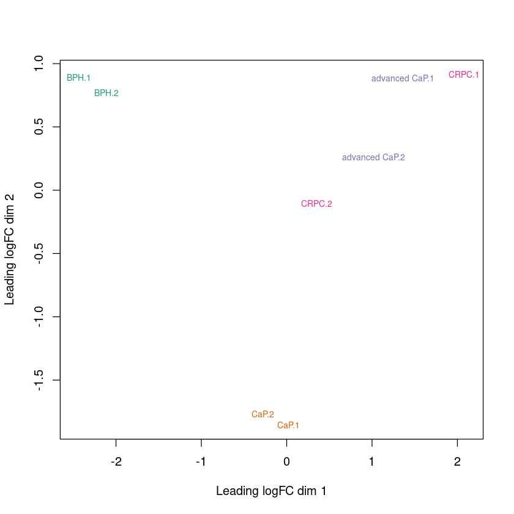

```python
%use r
plotMDS(my_dge, method="logFC", top=500, labels=my_dge$samples$sample.label, cex=0.7, col=group_cols)
```

The logFC MDS plot also shows a similar result.

### Hierarchical Clustering

We can confirm the MDS plots by hierarchical clustering.

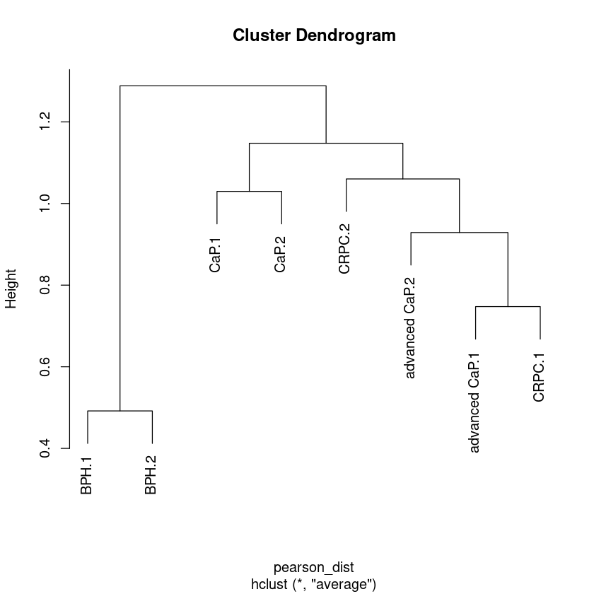

```python
%use r
rpkm_mean <- rowMeans(rpkm_norm)
rpkm_sd <- apply(rpkm_norm, 1, sd)
rpkm_zscores <- sweep(rpkm_norm, 1, rpkm_mean, "-")
rpkm_zscores <- sweep(rpkm_zscores, 1, rpkm_sd, "/")
pearson_dist <- cor(rpkm_zscores, method="pearson", use="everything")
pearson_dist <- as.dist(1 - pearson_dist)
my_hclust <- hclust(pearson_dist, "average")
my_hclust$labels <- pdata$sample.label
plot(my_hclust)
```

The two groups "CRPC" and "advanced CaP" are more similar to each other than to the control. That is an important point.

## Perform Statistical Tests

### exactTest

There are various methods in **edgeR** to compare groups. Here, we will use the **exactTest** that will do direct comparisons of the counts for two groups. This method performs well in benchmarking tests of **edgeR**, see [Schurch, et al](https://www.ncbi.nlm.nih.gov/pmc/articles/PMC4878611/) and is suitable for this experiment. Again, I recommend that you keep the default arguments unless you have good reason to change them.

The **pair** argument specifies the groups that you want to compare. Our first group is **BPH** and the 4th is **CRPC**, so **pair=c(1, 4)** is **CRPC / BPH**.

```python
%use r
crpc_et <- exactTest(my_dge, pair=c(1, 4), dispersion="auto",
                     rejection.region="deviance", big.count=900, prior.count=0.125)
# the options shown here are alll default values
```

### topTags

The **topTags** function will summarize the tests. I always select all genes and do not sort. The resulting object is a list with multiple elements, including a table of results. The **logFC** is the log2 ratio of the change between the two groups. And **FDR** is the p-value after adjusting for multiple testing. We use benjamini-hochberg procedure ("BH") for adjustment.

```python
%use r
crpc_tt <- topTags(crpc_et, n=nrow(my_dge), sort.by="none")
head(crpc_tt)
```

**$table**

A data.frame: 6 × 4

|  | logFC <dbl> | logCPM <dbl> | PValue <dbl> | FDR <dbl> |
| --- | --- | --- | --- | --- |
| 5_8S_rRNA | 3.2440274 | 7.4163047 | 0.0007793459 | 0.01261952 |
| 7SK | 0.8605985 | 1.0043867 | 0.5123260572 | 0.75827739 |
| A1BG | -2.1187503 | 0.6660056 | 0.0823775503 | 0.27493794 |
| A1BG-AS1 | -0.6528116 | 2.2502034 | 0.3442317604 | 0.61804610 |
| A2M | -1.4225184 | 9.4049985 | 0.0580297888 | 0.22139329 |
| A2M-AS1 | -0.2323530 | 7.4136852 | 0.7661513004 | 0.92054720 |

**$adjust.method**

'BH'

**$comparison**

1. 'BPH'

2. 'CRPC'

**$test**

'exact'

### decideTests

The **decideTestsDGE** will produce a vector of gene calls based on your specified cutoffs. We use the option `p.value` to specify the cut-off at 0.05. `lfc` is the minimum absolute log2 fold change required, so I just keep the default of 0.

The result is a table of either 0,1 or -1 for each genes, where **0** indicates no significant change between groups, **1** indicates a positive change or upregulated from control to treatment, and **-1** indicates a negative change or downregulated in expression.

```python
%use r
crpc_tests <- decideTestsDGE(crpc_et, adjust.method="BH", p.value=0.05, lfc=0)
head(crpc_tests)
```

A TestResults: 6 × 1 of type int

|  | CRPC-BPH |
| --- | --- |
| 5_8S_rRNA | 1 |
| 7SK | 0 |
| A1BG | 0 |
| A1BG-AS1 | 0 |
| A2M | 0 |
| A2M-AS1 | 0 |

We can summarize the differentially expressed genes (DEGs) with **table** to check how many differential genes we have.

```python
%use r
table(crpc_tests)
```

```
crpc_tests
   -1     0     1
 1276 15966   764
```

This table shows that we got 15966 insignificant genes, 764 genes with upregulated effects in CRPC and 1276 genes with downregulated effects in CRPC.

## Visualizing the Results

There are several ways to visually summarize the results of your experiment. A smear plot shows the relationship between gene counts and log fold-change. Differentially expressed genes can be highlighted. Each point is a gene and significant genes are highlighted in red.

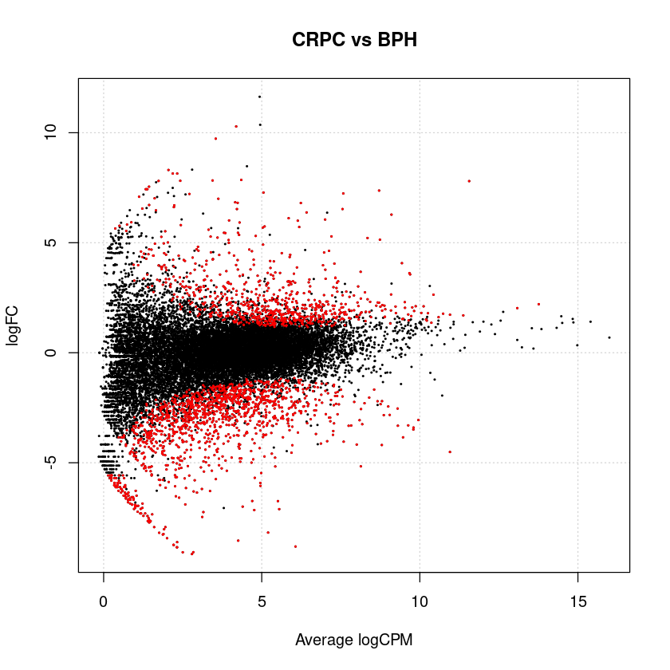

```python
%use r
plotSmear(crpc_et, de.tags=rownames(crpc_tt)[crpc_tests != 0], main="CRPC vs BPH")
```

It should not be surprising that genes with high average counts can have only modest log fold-changes, but still be considered statistically significant. As a researcher, you must decide if you want to set a log fold-change cutoff.

### Volcano Plots

Volcano plots visualize the relationship between FDR (-log10) and log2 fold-change. Still, each point is a gene. Genes with significant positive effect is highlighted in red while genes with negative effect is highlighted in blue.

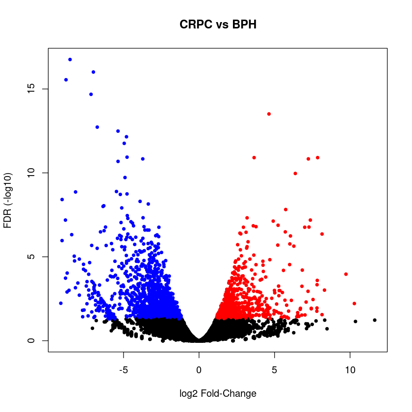

```python
%use r
plot(crpc_tt$table$logFC, -log10(crpc_tt$table$FDR),
     col=c("blue", "black", "red")[as.factor(crpc_tests)], ylab="FDR (-log10)",
     xlab="log2 Fold-Change", main="CRPC vs BPH", pch=20)
```

### Corrplots

Correlation plots can be used to demonstrate consistency between your replicates. Here we will do them only using the data for the DEGs.

```python
%use r
degs <- rownames(crpc_tests)[crpc_tests != 0]
head(degs)
```

1. '5_8S_rRNA'

2. 'AADAT'

3. 'AATBC'

4. 'ABCC3'

5. 'ABCC9'

6. 'ABHD11'

We can plot the correlation matrix between each sample using the corrplot Package.

```python
%use r
degs_zscores <- rpkm_zscores[degs, ]
colnames(degs_zscores) <- my_dge$samples$sample.label
head(degs_zscores)
```

A matrix: 6 × 8 of type dbl

|  | BPH.1 | BPH.2 | CaP.1 | CaP.2 | advanced CaP.1 | advanced CaP.2 | CRPC.1 | CRPC.2 |
| --- | --- | --- | --- | --- | --- | --- | --- | --- |
| 5_8S_rRNA | -0.7448715 | -0.7710087 | -0.7601200 | -0.001311483 | 0.1199051 | 0.3851456 | -0.4442377 | 2.2164987 |
| AADAT | -1.1629329 | -1.0151389 | -0.9014153 | 0.418926301 | 0.7260442 | 0.9557744 | 1.4138759 | -0.4351338 |
| AATBC | 1.7980371 | 1.4102614 | -0.6067728 | -0.404570393 | -0.6067728 | -0.3766370 | -0.6067728 | -0.6067728 |
| ABCC3 | 1.0945787 | 2.0220777 | -0.4288878 | -0.587299166 | -0.3499721 | -0.4640380 | -0.7405268 | -0.5459327 |
| ABCC9 | 1.2394837 | 1.8456298 | -0.2102908 | -0.607364875 | -0.3262262 | -0.5212977 | -1.0690879 | -0.3508459 |
| ABHD11 | -1.2012882 | -1.3254452 | 0.4124923 | 1.320577489 | -0.4116680 | 1.1501737 | -0.4152164 | 0.4703744 |

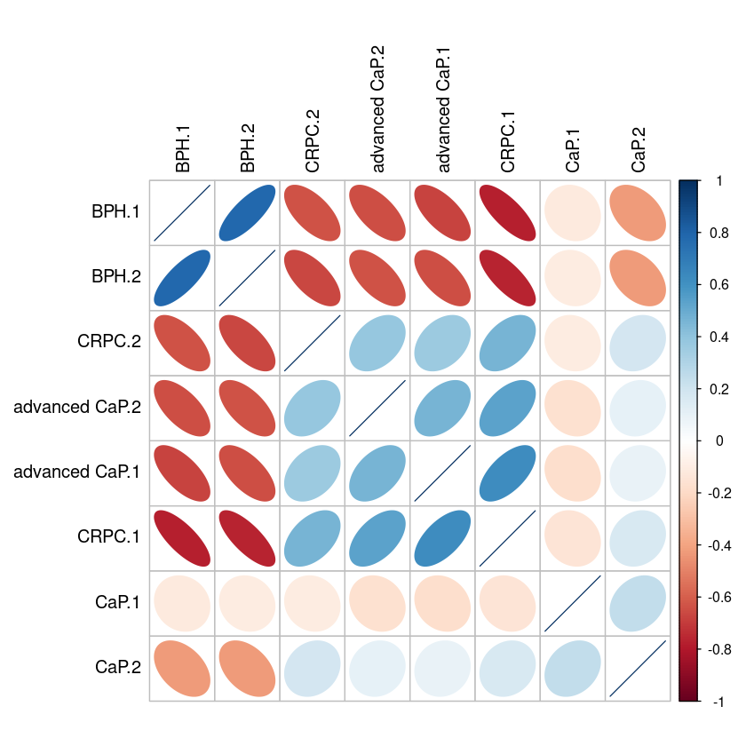

```python
%use r
# library(corrplot)
my_cor <- cor(degs_zscores, method="pearson")
corrplot(my_cor, method="ellipse", order="hclust", hclust.method="average", tl.col="black")
```

### Heatmaps

We can further examine the consistency between biological replicates with a heat map for the DEGs. There is an R package called **pheatmap** (pretty heatmaps) that take much of the work out of this task.

```python
%use r
library(pheatmap)
```

Make a topTable for only the DEGs, and sort it by increasing FDR.

```python
%use r
dge_tt <- crpc_tt$table[degs, ]
dge_tt <- dge_tt[order(dge_tt$FDR, decreasing=FALSE), ]
head(dge_tt)
```

A data.frame: 6 × 4

|  | logFC <dbl> | logCPM <dbl> | PValue <dbl> | FDR <dbl> |
| --- | --- | --- | --- | --- |
| MIR205HG | -8.540650 | 4.256601 | 9.726646e-22 | 1.751380e-17 |
| TRIM29 | -6.994650 | 4.396517 | 1.083225e-20 | 9.752273e-17 |
| KRT13 | -8.807980 | 6.069120 | 4.702831e-20 | 2.822639e-16 |
| SCGB1A1 | -7.150749 | 4.763376 | 4.605245e-19 | 2.073051e-15 |
| GDF15 | 4.631531 | 7.128788 | 8.536894e-18 | 3.074306e-14 |
| PIGR | -6.738995 | 4.699451 | 6.225494e-17 | 1.868271e-13 |

Get the gene symbols for the top 50 DEGs to use as an index for the zscores. Fifty is a reasonable number if you want to see the gene labels.

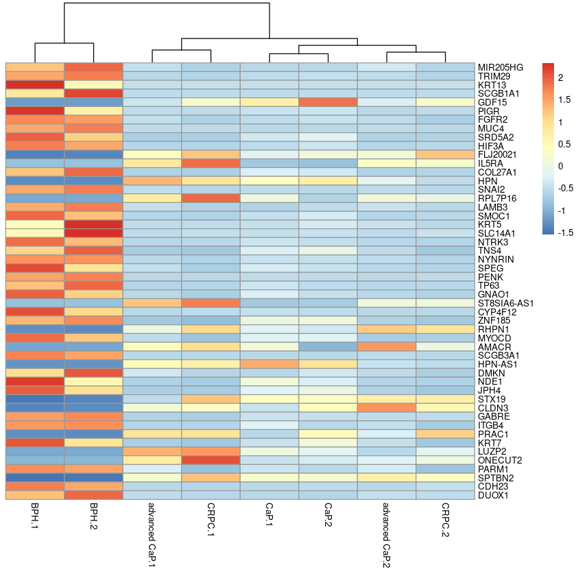

```python
%use r
gene_no <- 50
my_top <- rownames(dge_tt)[1:gene_no]
top_zscores <- rpkm_zscores[my_top, ]
colnames(top_zscores) <- my_dge$samples$sample.label
pheatmap(top_zscores, cluster_col=TRUE, cluster_rows=FALSE, clustering_distance_cols="euclidean",
        cluster_method="average",fontsize=8)
```

### Boxplots for Individual Genes

We can check the expression of the primary genes that stated by the authors to be associated with progression of CRPC. There is a large difference in expression level among the groups.

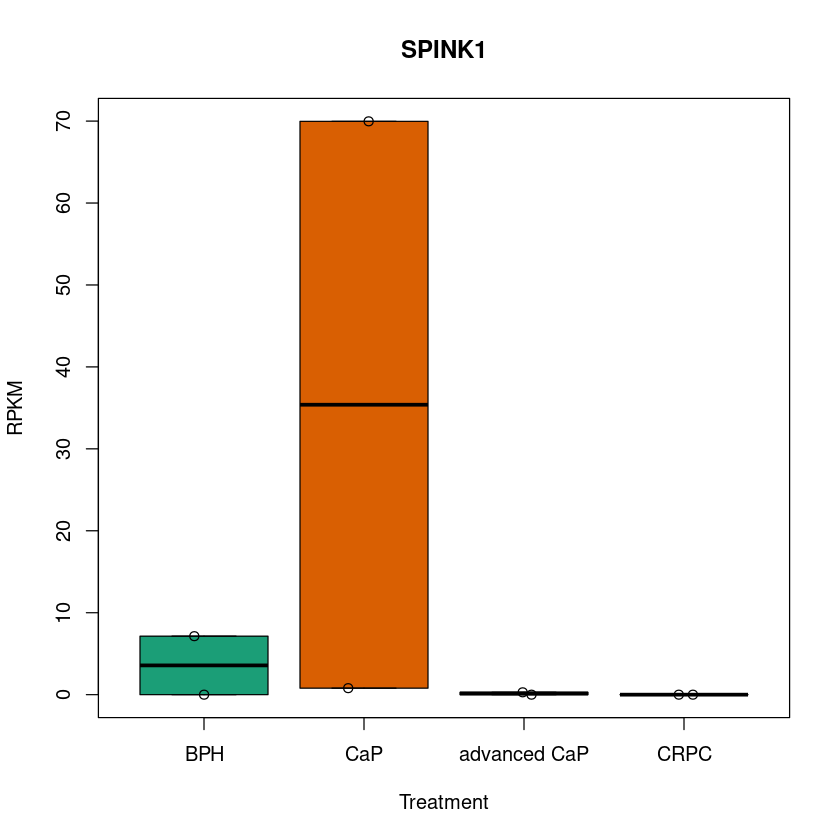

```python
%use r
my_gene <- "SPINK1"
boxplot(rpkm_norm[my_gene, ] ~ my_dge$sample$group, col=group_pal, main=my_gene, ylab="RPKM",
        xlab="Treatment")
stripchart(rpkm_norm[my_gene, ] ~ my_dge$sample$group, vertical=TRUE, method="jitter", jitter=0.1,
          add=TRUE, pch=1)
```

We can also check SP8 and AR.

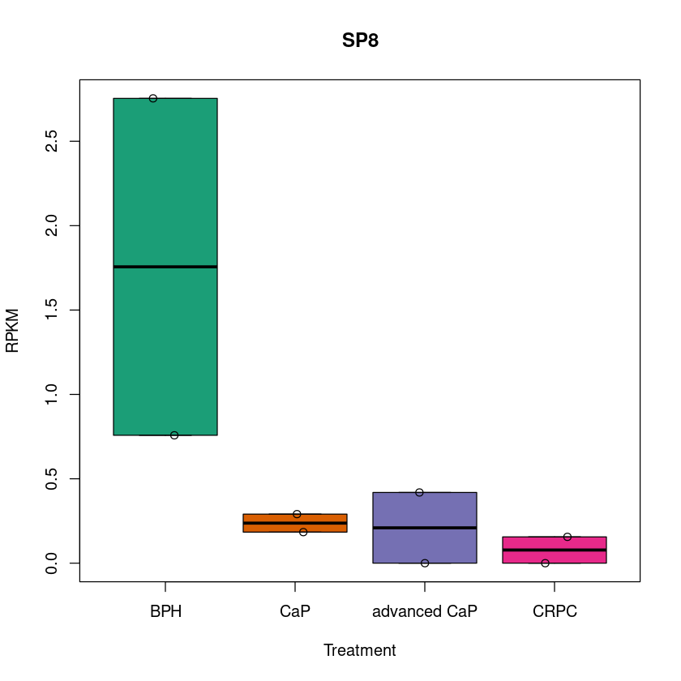

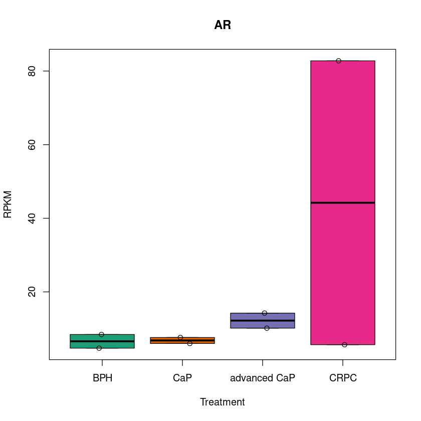

```python
%use r
my_gene <- "SP8"
boxplot(rpkm_norm[my_gene, ] ~ my_dge$sample$group, col=group_pal, main=my_gene, ylab="RPKM",
        xlab="Treatment")
stripchart(rpkm_norm[my_gene, ] ~ my_dge$sample$group, vertical=TRUE, method="jitter", jitter=0.1,
          add=TRUE, pch=1)

my_gene <- "AR"
boxplot(rpkm_norm[my_gene, ] ~ my_dge$sample$group, col=group_pal, main=my_gene, ylab="RPKM",
        xlab="Treatment")
stripchart(rpkm_norm[my_gene, ] ~ my_dge$sample$group, vertical=TRUE, method="jitter", jitter=0.1,
          add=TRUE, pch=1)
```

[Yun, et al., Oncotarget., 2017](https://www.ncbi.nlm.nih.gov/pmc/articles/PMC5777737/) claimed that 12 genes are associated with progression into CRPC, we can visualize these genes in a heatmap.

To avoid data entry error, I copy and pasted the gene list into my R code. However, I need to convert this long **character string** to a **character vector** of gene symbols, removing the commas in the process. If you ever attempt something similar, watch for hidden formatting characters such as **tabs** or **end-of-line**.

```python
%use r
crpc_up <- "AR, SPINK1"
crpc_up <- c(strsplit(crpc_up, split=", ")[[1]], recursive=TRUE)
print(crpc_up)
```

```
[1] "AR"     "SPINK1"
```

Same for the putative down-regulated genes.

```python
%use r
crpc_down <- "ALOX15B, ALOX15B, ANPEP, CBLN2, CEACAM20, CEACAM22P, SERPINB11, SNCA, SP8, TRPM8, WNT11"
crpc_down <- c(strsplit(crpc_down, split=", ")[[1]], recursive=TRUE)
crpc_down
```

1. 'ALOX15B'

2. 'ALOX15B'

3. 'ANPEP'

4. 'CBLN2'

5. 'CEACAM20'

6. 'CEACAM22P'

7. 'SERPINB11'

8. 'SNCA'

9. 'SP8'

10. 'TRPM8'

11. 'WNT11'

Now, we need to select only those genes that we have been able to examine in the RNA-seq experiment, i.e. we need to remove genes that were filtered.

```python
%use r
crpc_up <- intersect(crpc_up, rownames(rpkm_zscores))
crpc_down <- intersect(crpc_down, rownames(rpkm_zscores))
```

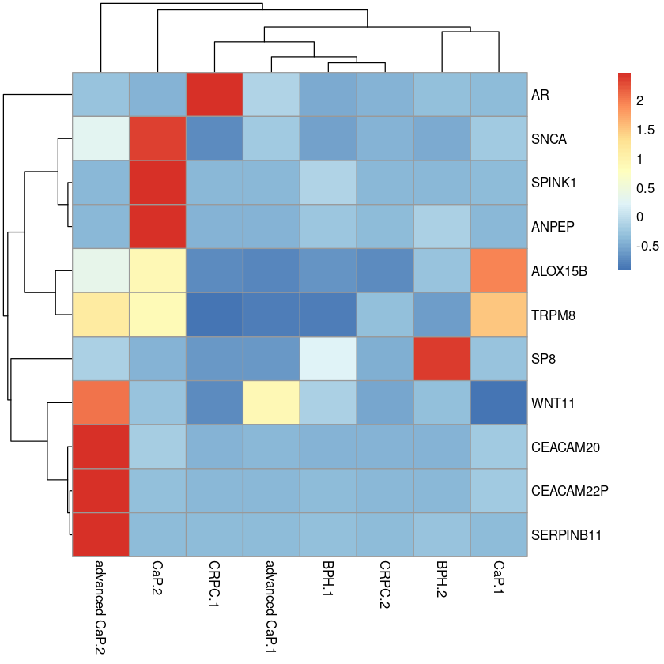

```python
%use r
crpc_all <- union(crpc_up, crpc_down)
crpc_zscores <- rpkm_zscores[crpc_all, ]
colnames(crpc_zscores) <- my_dge$samples$sample.label
pheatmap(crpc_zscores, cluster_col=TRUE, cluster_rows=TRUE, clustering_distance_cols="euclidean",
        cluster_method="average")
```

# Saving the results

A critical step of bioinformatics analysis is to carefully document all steps. This task is often ignored and publications frequently have inadequate documentation of data processing and analysis. This is one advantage of tools like Jupyter Notebooks or Rmarkdown (not covered in this course). The workflow from the RNA-seq Notebooks should be saved downloaded in at least two formats, HTML and R are recommended.

In addition, we will save the result to a tab-delimited text file that can be imported into Microsoft Excel or LibreOffice Calc. First, let's assemble the **edgeR** results in a single file.

```python
%use r
#library(data.table)
crpc_results <- crpc_tt$table
# crpc_results<- data.table(crpc_results)
crpc_results$test <- as.vector(crpc_tests)
crpc_results$SYMBOL <- rownames(crpc_results)
head(crpc_results)
```

A data.frame: 6 × 6

|  | logFC <dbl> | logCPM <dbl> | PValue <dbl> | FDR <dbl> | test <int> | SYMBOL <chr> |
| --- | --- | --- | --- | --- | --- | --- |
| 5_8S_rRNA | 3.2440274 | 7.4163047 | 0.0007793459 | 0.01261952 | 1 | 5_8S_rRNA |
| 7SK | 0.8605985 | 1.0043867 | 0.5123260572 | 0.75827739 | 0 | 7SK |
| A1BG | -2.1187503 | 0.6660056 | 0.0823775503 | 0.27493794 | 0 | A1BG |
| A1BG-AS1 | -0.6528116 | 2.2502034 | 0.3442317604 | 0.61804610 | 0 | A1BG-AS1 |
| A2M | -1.4225184 | 9.4049985 | 0.0580297888 | 0.22139329 | 0 | A2M |
| A2M-AS1 | -0.2323530 | 7.4136852 | 0.7661513004 | 0.92054720 | 0 | A2M-AS1 |

We are going to save all of the results as plain text, tab-delimited files. Use caution if you read these files into applications like Excel. Excel is notorious for changing gene symbols to dates! Carefully import the data and avoid using the General data format!

```python
%use r
if(!file.exists("results"))  dir.create("results")
```

```python
%use r
write.table(crpc_results, file.path("results", "CRPC_Results.txt"), row.names=FALSE, sep="\t",
            quote=FALSE)
write.table(my_dge$counts, file.path("results", "Counts_Filtered.txt"), row.names=TRUE, sep="\t",
            quote=FALSE)
write.table(rpkm_norm, file.path("results", "RPKM_Norm.txt"), row.names=TRUE, sep="\t",
            quote=FALSE)
```

# Gene Annotations

We saved our statistical analysis results at the end of last section. We will reload them into R before continuing the gene annotation.

```python
%use r
#library(data.table)
crpc_results <- read.table("./results/CRPC_Results.txt",  header=T,sep="\t")
head(crpc_results)
```

A data.frame: 6 × 6

|  | logFC <dbl> | logCPM <dbl> | PValue <dbl> | FDR <dbl> | test <int> | SYMBOL <chr> |
| --- | --- | --- | --- | --- | --- | --- |
| 1 | 3.2440274 | 7.4163047 | 0.0007793459 | 0.01261952 | 1 | 5_8S_rRNA |
| 2 | 0.8605985 | 1.0043867 | 0.5123260572 | 0.75827739 | 0 | 7SK |
| 3 | -2.1187503 | 0.6660056 | 0.0823775503 | 0.27493794 | 0 | A1BG |
| 4 | -0.6528116 | 2.2502034 | 0.3442317604 | 0.61804610 | 0 | A1BG-AS1 |
| 5 | -1.4225184 | 9.4049985 | 0.0580297888 | 0.22139329 | 0 | A2M |
| 6 | -0.2323530 | 7.4136852 | 0.7661513004 | 0.92054720 | 0 | A2M-AS1 |

We have the **edgeR** results for our genes, but we only have the gene symbol. It may be helpful to other gene identifiers. We could use a **Bioconductor** database as we did previously. This time, we are going to use a file from [Human Genome Nomenclature Committee website](https://www.genenames.org/cgi-bin/download).

```python
%use r
hgnc_genes <- read.delim("./data/HGNC_genes.txt", sep="\t", as.is=TRUE, header=TRUE)
head(hgnc_genes)
```

A data.frame: 6 × 10

|  | HGNC.ID <chr> | Approved.Symbol <chr> | Approved.Name <chr> | Status <chr> | Previous.Symbols <chr> | Synonyms <chr> | Chromosome <chr> | Accession.Numbers <chr> | Entrez.Gene.ID <int> | RefSeq.IDs <chr> |
| --- | --- | --- | --- | --- | --- | --- | --- | --- | --- | --- |
| 1 | HGNC:5 | A1BG | alpha-1-B glycoprotein | Approved |  |  | 19q13.43 |  | 1 | NM_130786 |
| 2 | HGNC:37133 | A1BG-AS1 | A1BG antisense RNA 1 | Approved | NCRNA00181, A1BGAS, A1BG-AS | FLJ23569 | 19q13.43 | BC040926 | 503538 | NR_015380 |
| 3 | HGNC:24086 | A1CF | APOBEC1 complementation factor | Approved |  | ACF, ASP, ACF64, ACF65, APOBEC1CF | 10q11.23 | AF271790 | 29974 | NM_014576 |
| 4 | HGNC:7 | A2M | alpha-2-macroglobulin | Approved |  | FWP007, S863-7, CPAMD5 | 12p13.31 | BX647329, X68728, M11313 | 2 | NM_000014 |
| 5 | HGNC:27057 | A2M-AS1 | A2M antisense RNA 1 (head to head) | Approved |  |  | 12p13.31 |  | 144571 | NR_026971 |
| 6 | HGNC:23336 | A2ML1 | alpha-2-macroglobulin like 1 | Approved | CPAMD9 | FLJ25179, p170 | 12p13.31 | AK057908 | 144568 | NM_144670 |

Let's see if we can map the symbols in our results to **Approved.Symbol**.

```python
%use r
table(crpc_results$SYMBOL %in% hgnc_genes$Approved.Symbol)
```

```
FALSE  TRUE
  979 17027
```

Seems like we are OK for most of our symbols. This does raise a concern though. We cannot be sure that we have the current HGNC approved symbol. Therefore, we need to search all possible fields in this file, **Approved.Symbol**, **Previous.Symbols** and **Synonyms**. We can use **grep** for this, but we need to be careful.

We cannot search with exact matching because there can be multiple symbols in each column. A simple pattern search with **grep** will also be a problem because of partial matches. To control for this, we need to use an actual **regular expression** to allow for only specific characters after our gene symbol.

For example, *C6orf1* will produce a partial match to any columns that contain this character string such as *C6orf12* or *C6orf100*. We cannot force an exact match because there could be more than one **Previous.Symbol**, so we need to allow for possibilities like *C6orf1,XXX* or *XXX,C6orf1* where *XXX* is another **Previous.Symbol**.

To do this, we are going to add two possibilities to the end of the symbol pattern. First, we want no characters to precede or follow the gene symbol, i.e. it is the only symbol in the column. We can indicate the start of the string with a carat, `^`, and the end of a string with a dollar sign, `$`, in our pattern. Second, we will allow for a comma that is used to separate multiple symbols. So, for any pattern, `XXX`, we will allow the following.

- `^XXX$` -- *C6orf1*
- `^XXX,` -- *C6orf1,*
- `,XXX$` -- *,C6orf1*
- `,XXX,` -- *,C6orf1,*

We are also going to allow for leading or trailing spaces. The R coding for these steps are complicated. Do not worry about that. The important point here is that it can be difficult to pull textual data from files or databases, especially when there are inconsistencies in data entry. Many web tools do this for you. However, I have always had concerns about accuracy.

Dealing with gene identifiers is always frustrating. This time, it is a bit more complicated because we are dealing with an earlier version of the human genome.

Please Note, the steps below are slow and will take about two minutes.

```python
%use r
approved <- lapply(crpc_results$SYMBOL, function(x)(
                    grepl(paste("(^|,| +)", x, "($|,| +)", sep=""),
                    hgnc_genes$Approved.Symbol, fixed=FALSE)))
names(approved) <- crpc_results$SYMBOL
```

Each element of **approved** is a **logical vector** that we sum to determine the number of hits.

```python
%use r
table(sapply(approved, sum))
```

```
    0     1
  979 17027
```

The number doesn't change. So we had over 17,000 hits and each is unique. Now we can reformat the data. The column **Result.Symbol** is added in the process. This is the symbol that we used in the gene count matrix.

```python
%use r
approved_data <- lapply(approved, function(x)(hgnc_genes[x, ]))
approved_data <- do.call(rbind, approved_data)
approved_data$Result.Symbol <- rownames(approved_data)
head(approved_data)
```

A data.frame: 6 × 11

|  | HGNC.ID <chr> | Approved.Symbol <chr> | Approved.Name <chr> | Status <chr> | Previous.Symbols <chr> | Synonyms <chr> | Chromosome <chr> | Accession.Numbers <chr> | Entrez.Gene.ID <int> | RefSeq.IDs <chr> | Result.Symbol <chr> |
| --- | --- | --- | --- | --- | --- | --- | --- | --- | --- | --- | --- |
| A1BG | HGNC:5 | A1BG | alpha-1-B glycoprotein | Approved |  |  | 19q13.43 |  | 1 | NM_130786 | A1BG |
| A1BG-AS1 | HGNC:37133 | A1BG-AS1 | A1BG antisense RNA 1 | Approved | NCRNA00181, A1BGAS, A1BG-AS | FLJ23569 | 19q13.43 | BC040926 | 503538 | NR_015380 | A1BG-AS1 |
| A2M | HGNC:7 | A2M | alpha-2-macroglobulin | Approved |  | FWP007, S863-7, CPAMD5 | 12p13.31 | BX647329, X68728, M11313 | 2 | NM_000014 | A2M |
| A2M-AS1 | HGNC:27057 | A2M-AS1 | A2M antisense RNA 1 (head to head) | Approved |  |  | 12p13.31 |  | 144571 | NR_026971 | A2M-AS1 |
| A2ML1 | HGNC:23336 | A2ML1 | alpha-2-macroglobulin like 1 | Approved | CPAMD9 | FLJ25179, p170 | 12p13.31 | AK057908 | 144568 | NM_144670 | A2ML1 |
| A2MP1 | HGNC:8 | A2MP1 | alpha-2-macroglobulin pseudogene 1 | Approved | A2MP |  | 12p13.31 | M24415 | 3 | NG_001067 | A2MP1 |

Now we can search **Previous.Symbol**. This step is slow and takes about 2 minutes.

```python
%use r
previous_sym <- lapply(crpc_results$SYMBOL, function(x)(
                        grepl(paste("(^|,| +)", x, "($|,| +)", sep=""),
                        hgnc_genes$Previous.Symbols, fixed=FALSE)))
names(previous_sym) <- crpc_results$SYMBOL
```

```python
%use r
table(sapply(previous_sym, sum))
```

```
    0     1     2     3
17916    88     1     1
```

We have two genes with more than one hit.

```python
%use r
which(sapply(previous_sym, sum)  > 1)
```

**NET1**

9882

**TRNP1**

16209

```python
%use r
previous_data <- lapply(previous_sym, function(x)(hgnc_genes[x, ]))
previous_data <- do.call(rbind, previous_data)
previous_data$Result.Symbol <- rownames(previous_data)
```

```python
%use r
head(previous_data)
```

A data.frame: 6 × 11

|  | HGNC.ID <chr> | Approved.Symbol <chr> | Approved.Name <chr> | Status <chr> | Previous.Symbols <chr> | Synonyms <chr> | Chromosome <chr> | Accession.Numbers <chr> | Entrez.Gene.ID <int> | RefSeq.IDs <chr> | Result.Symbol <chr> |
| --- | --- | --- | --- | --- | --- | --- | --- | --- | --- | --- | --- |
| ADCY3 | HGNC:239 | ADCY8 | adenylate cyclase 8 | Approved | ADCY3 | HBAC1, AC8 | 8q24.22 | Z35309 | 114 |  | ADCY3 |
| AK3 | HGNC:363 | AK4 | adenylate kinase 4 | Approved | AK3, AK3L1 |  | 1p31.3 | AK025926 | 205 | NM_013410 | AK3 |
| AK6 | HGNC:17376 | AK3 | adenylate kinase 3 | Approved | AK6, AK3L1 | AKL3L1 | 9p24.1 | BC013771 | 50808 | NM_016282 | AK6 |
| APPL2 | HGNC:598 | APLP2 | amyloid beta precursor like protein 2 | Approved | APPL2 | APPH | 11q24.3 | L19597 | 334 | NM_001642 | APPL2 |
| ARFGAP1 | HGNC:661 | ARFGAP3 | ADP ribosylation factor GTPase activating protein 3 | Approved | ARFGAP1 |  | 22q13.2 | AK002083 | 26286 | NM_014570 | ARFGAP1 |
| B3GNT6 | HGNC:15685 | B4GAT1 | beta-1,4-glucuronyltransferase 1 | Approved | B3GNT6, B3GNT1 | iGNT, iGAT, iGnT, BETA3GNTI, B3GN-T1 | 11q13.2 | AF029893 | 11041 | NM_006876 | B3GNT6 |

Now, search the **Synonyms** column. This step also takes about 2 minutes.

```python
%use r
synonym <- lapply(crpc_results$SYMBOL, function(x)(
                    grepl(paste("(^|,| +)", x, "($|,| +)", sep=""),
                    hgnc_genes$Synonyms, fixed=FALSE)))
names(synonym) <- crpc_results$SYMBOL
```

```python
%use r
which(sapply(synonym, sum) > 1)
```

**APC2**

776

**ATR**

1226

**BAP1**

1334

**CAD**

1910

**CAST**

2039

**CHD5**

2722

**CNR1**

3018

**DAP**

3580

**DBP**

3608

**DLC1**

3880

**EBP**

4239

**FHL1**

5221

**GCOM1**

5627

**GOT1**

5905

**GRIP1**

6057

**HGF**

6398

**HK1**

6441

**HK2**

6442

**IMP3**

7012

**ME2**

8760

**MIP**

8973

**MTF1**

9424

**PAN2**

10630

**POP1**

11531

**RAD1**

12254

**RIF1**

12663

**RP2**

12884

**SCP2**

13446

**U3**

16469

```python
%use r
synonym_data <- lapply(synonym, function(x)(hgnc_genes[x, ]))
synonym_data <- do.call(rbind, synonym_data)
synonym_data$Result.Symbol <- rownames(synonym_data)
head(synonym_data)
```

A data.frame: 6 × 11

|  | HGNC.ID <chr> | Approved.Symbol <chr> | Approved.Name <chr> | Status <chr> | Previous.Symbols <chr> | Synonyms <chr> | Chromosome <chr> | Accession.Numbers <chr> | Entrez.Gene.ID <int> | RefSeq.IDs <chr> | Result.Symbol <chr> |
| --- | --- | --- | --- | --- | --- | --- | --- | --- | --- | --- | --- |
| 7SK | HGNC:10037 | RN7SK | RNA, 7SK small nuclear | Approved |  | 7SK | 6p12.2 | X05490, X04236 | 125050 | NR_001445 | 7SK |
| ACAT2 | HGNC:11178 | SOAT2 | sterol O-acyltransferase 2 | Approved |  | ACAT2 | 12q13.13 | AF059203 | 8435 |  | ACAT2 |
| ACP1 | HGNC:7694 | NDUFAB1 | NADH:ubiquinone oxidoreductase subunit AB1 | Approved |  | SDAP, FASN2A, ACP, ACP1 | 16p12.2 | AF087660 | 4706 | NM_005003 | ACP1 |
| ACP3 | HGNC:125 | ACPP | acid phosphatase, prostate | Approved |  | ACP3, ACP-3, PAP | 3q22.1 |  | 55 | NM_001099 | ACP3 |
| ACTBP2 | HGNC:141 | ACTBP8 | actin, beta pseudogene 8 | Approved |  | ACTBP2 | 6q15 | V00481 | 68 | NG_000840 | ACTBP2 |
| ADA2 | HGNC:11531 | TADA2A | transcriptional adaptor 2A | Approved | TADA2L | ADA2, hADA2, ADA2A | 17q12 | AK022767 | 6871 | NM_001488 | ADA2 |

Now we can combine the search results from the three fields.

```python
%use r
all_genes <- rbind(approved_data, previous_data, synonym_data)
all_genes <- all_genes[order(all_genes$Result.Symbol), ]
rownames(all_genes) <- NULL
head(all_genes)
```

A data.frame: 6 × 11

|  | HGNC.ID <chr> | Approved.Symbol <chr> | Approved.Name <chr> | Status <chr> | Previous.Symbols <chr> | Synonyms <chr> | Chromosome <chr> | Accession.Numbers <chr> | Entrez.Gene.ID <int> | RefSeq.IDs <chr> | Result.Symbol <chr> |
| --- | --- | --- | --- | --- | --- | --- | --- | --- | --- | --- | --- |
| 1 | HGNC:10037 | RN7SK | RNA, 7SK small nuclear | Approved |  | 7SK | 6p12.2 | X05490, X04236 | 125050 | NR_001445 | 7SK |
| 2 | HGNC:5 | A1BG | alpha-1-B glycoprotein | Approved |  |  | 19q13.43 |  | 1 | NM_130786 | A1BG |
| 3 | HGNC:37133 | A1BG-AS1 | A1BG antisense RNA 1 | Approved | NCRNA00181, A1BGAS, A1BG-AS | FLJ23569 | 19q13.43 | BC040926 | 503538 | NR_015380 | A1BG-AS1 |
| 4 | HGNC:7 | A2M | alpha-2-macroglobulin | Approved |  | FWP007, S863-7, CPAMD5 | 12p13.31 | BX647329, X68728, M11313 | 2 | NM_000014 | A2M |
| 5 | HGNC:27057 | A2M-AS1 | A2M antisense RNA 1 (head to head) | Approved |  |  | 12p13.31 |  | 144571 | NR_026971 | A2M-AS1 |
| 6 | HGNC:23336 | A2ML1 | alpha-2-macroglobulin like 1 | Approved | CPAMD9 | FLJ25179, p170 | 12p13.31 | AK057908 | 144568 | NM_144670 | A2ML1 |

We can flag the duplicated genes.

```python
%use r
all_genes$Duplicated <- duplicated(all_genes$Result.Symbol, fromLast=FALSE) | duplicated(all_genes$Result.Symbol, fromLast=TRUE)
table(all_genes$Duplicated)
```

```
FALSE  TRUE
16752   781
```

```python
%use r
all_genes[all_genes$Duplicated, ]
```

A data.frame: 781 × 12

|  | HGNC.ID <chr> | Approved.Symbol <chr> | Approved.Name <chr> | Status <chr> | Previous.Symbols <chr> | Synonyms <chr> | Chromosome <chr> | Accession.Numbers <chr> | Entrez.Gene.ID <int> | RefSeq.IDs <chr> | Result.Symbol <chr> | Duplicated <lgl> |
| --- | --- | --- | --- | --- | --- | --- | --- | --- | --- | --- | --- | --- |
| 130 | HGNC:94 | ACAT2 | acetyl-CoA acetyltransferase 2 | Approved |  |  | 6q25.3 | AF356877 | 39 | NM_005891 | ACAT2 | TRUE |
| 131 | HGNC:11178 | SOAT2 | sterol O-acyltransferase 2 | Approved |  | ACAT2 | 12q13.13 | AF059203 | 8435 |  | ACAT2 | TRUE |
| 166 | HGNC:122 | ACP1 | acid phosphatase 1 | Approved |  | HAAP, LMW-PTP, LMWPTP | 2p25.3 | M87546 | 52 | NM_004300 | ACP1 | TRUE |
| 167 | HGNC:7694 | NDUFAB1 | NADH:ubiquinone oxidoreductase subunit AB1 | Approved |  | SDAP, FASN2A, ACP, ACP1 | 16p12.2 | AF087660 | 4706 | NM_005003 | ACP1 | TRUE |
| 191 | HGNC:135 | ACTBP2 | actin, beta pseudogene 2 | Approved |  |  | 5q14.1 |  | 62 | NG_003019 | ACTBP2 | TRUE |
| 192 | HGNC:141 | ACTBP8 | actin, beta pseudogene 8 | Approved |  | ACTBP2 | 6q15 | V00481 | 68 | NG_000840 | ACTBP2 | TRUE |
| 224 | HGNC:1839 | ADA2 | adenosine deaminase 2 | Approved | IDGFL, CECR1 | ADGF | 22q11.1 | AF190746 | 51816 |  | ADA2 | TRUE |
| 225 | HGNC:11531 | TADA2A | transcriptional adaptor 2A | Approved | TADA2L | ADA2, hADA2, ADA2A | 17q12 | AK022767 | 6871 | NM_001488 | ADA2 | TRUE |
| 237 | HGNC:202 | ADAM23 | ADAM metallopeptidase domain 23 | Approved |  | MDC3 | 2q33.3 | AB009672 | 8745 | NM_003812 | ADAM23 | TRUE |
| 238 | HGNC:206 | ADAM28 | ADAM metallopeptidase domain 28 | Approved |  | eMDCII, MDC-Lm, MDC-Ls, ADAM23 | 8p21.2 | AJ242015 | 10863 | NM_021778 | ADAM23 | TRUE |
| 285 | HGNC:234 | ADCY3 | adenylate cyclase 3 | Approved |  | AC3 | 2p23.3 | AF033861 | 109 |  | ADCY3 | TRUE |
| 286 | HGNC:239 | ADCY8 | adenylate cyclase 8 | Approved | ADCY3 | HBAC1, AC8 | 8q24.22 | Z35309 | 114 |  | ADCY3 | TRUE |
| 348 | HGNC:277 | ADRA1A | adrenoceptor alpha 1A | Approved | ADRA1C | ADRA1L1 | 8p21.2 | L31774 | 148 | NM_033303 | ADRA1A | TRUE |
| 349 | HGNC:280 | ADRA1D | adrenoceptor alpha 1D | Approved |  | ADRA1R, ADRA1A, ADRA1 | 20p13 | U03864 | 146 | NM_000678 | ADRA1A | TRUE |
| 417 | HGNC:333 | AGT | angiotensinogen | Approved | SERPINA8 |  | 1q42.2 | K02215 | 183 | NM_000029 | AGT | TRUE |
| 418 | HGNC:341 | AGXT | alanine-glyoxylate aminotransferase | Approved | SPAT | AGXT1, PH1, AGT, SPT, AGT1 | 2q37.3 | D13368 | 189 | NM_000030 | AGT | TRUE |
| 443 | HGNC:358 | AIP | aryl hydrocarbon receptor interacting protein | Approved |  | XAP2, ARA9, FKBP16 | 11q13.2 | U31913 | 9049 |  | AIP | TRUE |
| 444 | HGNC:24114 | AURKAIP1 | aurora kinase A interacting protein 1 | Approved |  | AKIP, AIP, FLJ20608 | 1p36.33 |  | 54998 | NM_017900 | AIP | TRUE |
| 450 | HGNC:17376 | AK3 | adenylate kinase 3 | Approved | AK6, AK3L1 | AKL3L1 | 9p24.1 | BC013771 | 50808 | NM_016282 | AK3 | TRUE |
| 451 | HGNC:363 | AK4 | adenylate kinase 4 | Approved | AK3, AK3L1 |  | 1p31.3 | AK025926 | 205 | NM_013410 | AK3 | TRUE |
| 456 | HGNC:49151 | AK6 | adenylate kinase 6 | Approved |  | CINAP | 5q13.2 |  | 102157402 | NM_016283 | AK6 | TRUE |
| 457 | HGNC:17376 | AK3 | adenylate kinase 3 | Approved | AK6, AK3L1 | AKL3L1 | 9p24.1 | BC013771 | 50808 | NM_016282 | AK6 | TRUE |
| 493 | HGNC:399 | ALB | albumin | Approved |  |  | 4q13.3 | V00494 | 213 | NM_000477 | ALB | TRUE |
| 494 | HGNC:24674 | FBF1 | Fas binding factor 1 | Approved |  | FLJ00103, FBF-1, KIAA1863, ALB | 17q25.1 | AK074045 | 85302 | NM_001080542 | ALB | TRUE |
| 579 | HGNC:14604 | AMN | amnion associated transmembrane protein | Approved |  | amnionless | 14q32.32 | AF328788 | 81693 |  | AMN | TRUE |
| 580 | HGNC:61 | ABCD1 | ATP binding cassette subfamily D member 1 | Approved | ALD | AMN, ALDP, adrenoleukodystrophy | Xq28 | Z21876 | 215 | NM_000033 | AMN | TRUE |
| 809 | HGNC:18242 | APPL2 | adaptor protein, phosphotyrosine interacting with PH domain and leucine zipper 2 | Approved |  | FLJ10659, DIP13B | 12q23.3 | AY113704 | 55198 | NM_018171 | APPL2 | TRUE |
| 810 | HGNC:598 | APLP2 | amyloid beta precursor like protein 2 | Approved | APPL2 | APPH | 11q24.3 | L19597 | 334 | NM_001642 | APPL2 | TRUE |
| 822 | HGNC:644 | AR | androgen receptor | Approved | DHTR, SBMA | AIS, NR3C4, SMAX1, HUMARA | Xq12 | M20132 | 367 | NM_000044 | AR | TRUE |
| 823 | HGNC:381 | AKR1B1 | aldo-keto reductase family 1 member B | Approved | ALDR1 | AR | 7q33 | J04795 | 231 | NM_001628 | AR | TRUE |
| ⋮ | ⋮ | ⋮ | ⋮ | ⋮ | ⋮ | ⋮ | ⋮ | ⋮ | ⋮ | ⋮ | ⋮ | ⋮ |
| 16274 | HGNC:12614 | USP16 | ubiquitin specific peptidase 16 | Approved |  | Ubp-M | 21q21 | AF126736 | NA |  | USP16 | TRUE |
| 16275 | HGNC:12620 | USP21 | ubiquitin specific peptidase 21 | Approved | USP23 | USP16 | 1q23.3 | AF177758 | 27005 |  | USP16 | TRUE |
| 16280 | HGNC:12620 | USP21 | ubiquitin specific peptidase 21 | Approved | USP23 | USP16 | 1q23.3 | AF177758 | 27005 |  | USP21 | TRUE |
| 16281 | HGNC:12624 | USP25 | ubiquitin specific peptidase 25 | Approved |  | USP21 | 21q21.1 | AF170562 | 29761 |  | USP21 | TRUE |
| 16291 | HGNC:20060 | USP31 | ubiquitin specific peptidase 31 | Approved |  | KIAA1203 | 16p12.2 | AB033029 | 57478 | NM_020718 | USP31 | TRUE |
| 16292 | HGNC:18533 | USP48 | ubiquitin specific peptidase 48 | Approved | USP31 | FLJ23277, FLJ11328, FLJ20103, FLJ23054, MGC14879 | 1p36.12 | AF502942 | 84196 | NM_032236 | USP31 | TRUE |
| 16360 | HGNC:21642 | VARS2 | valyl-tRNA synthetase 2, mitochondrial | Approved | VARS2L, VARSL | DKFZP434L1435, KIAA1885, G7a | 6p21.33 | AB067472 | 57176 | NM_020442 | VARS2 | TRUE |
| 16361 | HGNC:12651 | VARS | valyl-tRNA synthetase | Approved | VARS2 |  | 6p21.33 | BC012808 | 7407 | NM_006295 | VARS2 | TRUE |
| 16367 | HGNC:16919 | VAT1 | vesicle amine transport 1 | Approved |  | VATI, FLJ20230 | 17q21.31 | U18009 | 10493 | NM_006373 | VAT1 | TRUE |
| 16368 | HGNC:10934 | SLC18A1 | solute carrier family 18 member A1 | Approved | VMAT1, VAT1 | CGAT | 8p21.3 |  | 6570 |  | VAT1 | TRUE |
| 16386 | HGNC:12674 | VDAC3 | voltage dependent anion channel 3 | Approved |  | HD-VDAC3 | 8p11.21 | AF038962 | 7419 |  | VDAC3 | TRUE |
| 16387 | HGNC:12676 | VDAC1P5 | voltage dependent anion channel 1 pseudogene 5 | Approved | VDAC3, VDAC5P |  | 12q13.2 | S75494 | 10187 | NG_000882 | VDAC3 | TRUE |
| 16405 | HGNC:12693 | VIP | vasoactive intestinal peptide | Approved |  |  | 6q25.2 |  | 7432 |  | VIP | TRUE |
| 16406 | HGNC:23228 | CPAMD8 | C3 and PZP like, alpha-2-macroglobulin domain containing 8 | Approved |  | KIAA1283, VIP, K-CAP | 19p13.11 | AY101765 | 27151 | NM_015692 | VIP | TRUE |
| 16516 | HGNC:12737 | WBP1 | WW domain binding protein 1 | Approved |  | WBP-1 | 2p13.1 | U79457 | 23559 | NM_012477 | WBP1 | TRUE |
| 16517 | HGNC:2728 | DDOST | dolichyl-diphosphooligosaccharide--protein glycosyltransferase non-catalytic subunit | Approved |  | OST, KIAA0115, OST48, WBP1, GATD6 | 1p36.12 | D29643 | 1650 | NM_005216 | WBP1 | TRUE |
| 16532 | HGNC:13831 | WDR11 | WD repeat domain 11 | Approved | BRWD2 | KIAA1351, FLJ10506, WDR15, HH14, DR11, SRI1 | 10q26.12 | AF320223 | 55717 |  | WDR11 | TRUE |
| 16533 | HGNC:15673 | PHIP | pleckstrin homology domain interacting protein | Approved | WDR11 | ndrp, FLJ20705, DCAF14, BRWD2 | 6q14.1 | AF310250 | 55023 |  | WDR11 | TRUE |
| 16578 | HGNC:28826 | WDR82 | WD repeat domain 82 | Approved | TMEM113 | PRO2730, MST107, MSTP107, PRO34047, WDR82A, SWD2 | 3p21.2 | AF132207 | 80335 | NM_025222 | WDR82 | TRUE |
| 16579 | HGNC:32447 | WDR82P1 | WD repeat domain 82 pseudogene 1 | Approved | WDR82 | SW2, hCG26824, WDR82B | 3q11.2 |  | 728505 | XM_001127580 | WDR82 | TRUE |
| 16650 | HGNC:12801 | XBP1 | X-box binding protein 1 | Approved | XBP2 |  | 22q12.1 | M31627 | 7494 | NM_005080 | XBP1 | TRUE |
| 16651 | HGNC:12802 | XBP1P1 | X-box binding protein 1 pseudogene 1 | Approved | XBP1, XBPP1 |  | 5q22.2 |  | 7495 |  | XBP1 | TRUE |
| 16998 | HGNC:12992 | ZNF20 | zinc finger protein 20 | Approved |  | KOX13 | 19p13.2 | X52344 | 7568 | NM_021143 | ZNF20 | TRUE |
| 16999 | HGNC:12904 | ZNF121 | zinc finger protein 121 | Approved | D19S204 | ZHC32, ZNF20 | 19p13.2 | M99593 | 7675 | NM_001008727 | ZNF20 | TRUE |
| 17018 | HGNC:13018 | ZNF225 | zinc finger protein 225 | Approved |  |  | 19q13.31 | AF187991 | 7768 |  | ZNF225 | TRUE |
| 17019 | HGNC:3238 | EGR1 | early growth response 1 | Approved |  | TIS8, G0S30, NGFI-A, KROX-24, ZIF-268, AT225, ZNF225 | 5q31.2 | M62829 | 1958 | NM_001964 | ZNF225 | TRUE |
| 17024 | HGNC:13024 | ZNF230 | zinc finger protein 230 | Approved |  | FDZF2 | 19q13.31 | U95044 | 7773 |  | ZNF230 | TRUE |
| 17025 | HGNC:21159 | RNF141 | ring finger protein 141 | Approved |  | ZFP26, ZNF230 | 11p15.3 | AF214680 | 50862 | NM_016422 | ZNF230 | TRUE |
| 17086 | HGNC:23640 | ZNF322 | zinc finger protein 322 | Approved | ZNF489, ZNF388, HCG12, ZNF322A | bA457M11.3, bA457M11.2 | 6p22.2 | AY376736 | 79692 | NM_024639 | ZNF322 | TRUE |
| 17087 | HGNC:14003 | ZNF322P1 | zinc finger protein 322 pseudogene 1 | Approved | ZNF322, ZNF322B |  | 9q22.33 |  | 387328 | NM_199005 | ZNF322 | TRUE |

One way to distinguish genes with multiple annotations is by chromosome. We can add this to **crpc_results**.

```python
%use r
load("./data/GenesByExons.RData")
gene_chr <- unlist(runValue(seqnames(genesByExon_gr)))
gene_chr <- gene_chr[crpc_results$SYMBOL]
head(gene_chr)
```

**5_8S_rRNA**

14

**7SK**

1

**A1BG**

19

**A1BG-AS1**

19

**A2M**

12

**A2M-AS1**

12

**Levels**:**

1. '1'

2. '2'

3. '3'

4. '4'

5. '5'

6. '6'

7. '7'

8. 'X'

9. '8'

10. '9'

11. '11'

12. '10'

13. '12'

14. '13'

15. '14'

16. '15'

17. '16'

18. '17'

19. '18'

20. '20'

21. '19'

22. 'Y'

23. '22'

24. '21'

25. 'MT'

26. 'KI270728.1'

27. 'KI270727.1'

28. 'KI270442.1'

29. 'GL000225.1'

30. 'GL000009.2'

31. 'GL000194.1'

32. 'GL000205.2'

33. 'GL000195.1'

34. 'KI270733.1'

35. 'GL000219.1'

36. 'GL000216.2'

37. 'KI270744.1'

38. 'KI270734.1'

39. 'GL000213.1'

40. 'GL000220.1'

41. 'GL000218.1'

42. 'KI270731.1'

43. 'KI270750.1'

44. 'KI270721.1'

45. 'KI270726.1'

46. 'KI270711.1'

47. 'KI270713.1'

```python
%use r
crpc_results$gene_chr <- gene_chr
head(crpc_results)
```

A data.frame: 6 × 7

|  | logFC <dbl> | logCPM <dbl> | PValue <dbl> | FDR <dbl> | test <int> | SYMBOL <chr> | gene_chr <fct> |
| --- | --- | --- | --- | --- | --- | --- | --- |
| 1 | 3.2440274 | 7.4163047 | 0.0007793459 | 0.01261952 | 1 | 5_8S_rRNA | 14 |
| 2 | 0.8605985 | 1.0043867 | 0.5123260572 | 0.75827739 | 0 | 7SK | 1 |
| 3 | -2.1187503 | 0.6660056 | 0.0823775503 | 0.27493794 | 0 | A1BG | 19 |
| 4 | -0.6528116 | 2.2502034 | 0.3442317604 | 0.61804610 | 0 | A1BG-AS1 | 19 |
| 5 | -1.4225184 | 9.4049985 | 0.0580297888 | 0.22139329 | 0 | A2M | 12 |
| 6 | -0.2323530 | 7.4136852 | 0.7661513004 | 0.92054720 | 0 | A2M-AS1 | 12 |

Now, we can **merge** this with the **crpc_results**. The amount of gene annotation data may seem like overkill, but it is better to be safe because of the uncertaintiy of mapping gene identifiers.

```python
%use r
crpc_results <- merge(crpc_results, all_genes, by.x="SYMBOL", by.y="Result.Symbol", all.x=TRUE)
```

```python
%use r
crpc_results <- crpc_results[order(crpc_results$SYMBOL), ]
head(crpc_results, n=6)
```

A data.frame: 6 × 18

|  | SYMBOL <chr> | logFC <dbl> | logCPM <dbl> | PValue <dbl> | FDR <dbl> | test <int> | gene_chr <fct> | HGNC.ID <chr> | Approved.Symbol <chr> | Approved.Name <chr> | Status <chr> | Previous.Symbols <chr> | Synonyms <chr> | Chromosome <chr> | Accession.Numbers <chr> | Entrez.Gene.ID <int> | RefSeq.IDs <chr> | Duplicated <lgl> |
| --- | --- | --- | --- | --- | --- | --- | --- | --- | --- | --- | --- | --- | --- | --- | --- | --- | --- | --- |
| 1 | 5_8S_rRNA | 3.2440274 | 7.4163047 | 0.0007793459 | 0.01261952 | 1 | 14 | NA | NA | NA | NA | NA | NA | NA | NA | NA | NA | NA |
| 2 | 7SK | 0.8605985 | 1.0043867 | 0.5123260572 | 0.75827739 | 0 | 1 | HGNC:10037 | RN7SK | RNA, 7SK small nuclear | Approved |  | 7SK | 6p12.2 | X05490, X04236 | 125050 | NR_001445 | FALSE |
| 3 | A1BG | -2.1187503 | 0.6660056 | 0.0823775503 | 0.27493794 | 0 | 19 | HGNC:5 | A1BG | alpha-1-B glycoprotein | Approved |  |  | 19q13.43 |  | 1 | NM_130786 | FALSE |
| 4 | A1BG-AS1 | -0.6528116 | 2.2502034 | 0.3442317604 | 0.61804610 | 0 | 19 | HGNC:37133 | A1BG-AS1 | A1BG antisense RNA 1 | Approved | NCRNA00181, A1BGAS, A1BG-AS | FLJ23569 | 19q13.43 | BC040926 | 503538 | NR_015380 | FALSE |
| 5 | A2M | -1.4225184 | 9.4049985 | 0.0580297888 | 0.22139329 | 0 | 12 | HGNC:7 | A2M | alpha-2-macroglobulin | Approved |  | FWP007, S863-7, CPAMD5 | 12p13.31 | BX647329, X68728, M11313 | 2 | NM_000014 | FALSE |
| 6 | A2M-AS1 | -0.2323530 | 7.4136852 | 0.7661513004 | 0.92054720 | 0 | 12 | HGNC:27057 | A2M-AS1 | A2M antisense RNA 1 (head to head) | Approved |  |  | 12p13.31 |  | 144571 | NR_026971 | FALSE |

Let's reformat the **Chromosome** information from HGNC to make it consistent with our annotation.

```python
%use r
hgnc_chr <- sapply(crpc_results$Chromosome, function(x)(strsplit(x, split="p|q")[[1]][1]))
crpc_results$hgnc.chr <- hgnc_chr
table(crpc_results$hgnc.chr)
```

```
           1           10           11           12           13           14
        1766          682          955          887          325          599
       14 un           15           16           17           18           19
           1          594          765         1044          247         1209
           2           20           21           22        22 un            3
        1172          476          189          460            1          984
           4            5            6            7            8            9
         609          785          861          874          583          703
           X            Y mitochondria           un
         631           34           27            1
```

Apparently, we have some genes with no chromosome!

```python
%use r
dim(crpc_results[hgnc_chr == "NA", ]) # 934 genes with no chromosome
head(crpc_results[hgnc_chr == "NA", ],  6)
```

1. 934

2. 19

A data.frame: 6 × 19

|  | SYMBOL <chr> | logFC <dbl> | logCPM <dbl> | PValue <dbl> | FDR <dbl> | test <int> | gene_chr <fct> | HGNC.ID <chr> | Approved.Symbol <chr> | Approved.Name <chr> | Status <chr> | Previous.Symbols <chr> | Synonyms <chr> | Chromosome <chr> | Accession.Numbers <chr> | Entrez.Gene.ID <int> | RefSeq.IDs <chr> | Duplicated <lgl> | hgnc.chr <chr> |
| --- | --- | --- | --- | --- | --- | --- | --- | --- | --- | --- | --- | --- | --- | --- | --- | --- | --- | --- | --- |
| NA | NA | NA | NA | NA | NA | NA | NA | NA | NA | NA | NA | NA | NA | NA | NA | NA | NA | NA | NA |
| NA.1 | NA | NA | NA | NA | NA | NA | NA | NA | NA | NA | NA | NA | NA | NA | NA | NA | NA | NA | NA |
| NA.2 | NA | NA | NA | NA | NA | NA | NA | NA | NA | NA | NA | NA | NA | NA | NA | NA | NA | NA | NA |
| NA.3 | NA | NA | NA | NA | NA | NA | NA | NA | NA | NA | NA | NA | NA | NA | NA | NA | NA | NA | NA |
| NA.4 | NA | NA | NA | NA | NA | NA | NA | NA | NA | NA | NA | NA | NA | NA | NA | NA | NA | NA | NA |
| NA.5 | NA | NA | NA | NA | NA | NA | NA | NA | NA | NA | NA | NA | NA | NA | NA | NA | NA | NA | NA |

We still have the issue of genes with duplicated entries. We could try additional computational filters, e.g. remove entries where the HGNC chromosome does not match the GTF chromosome. However, it is probably better to evaluate each of these genes manually.

```python
%use r
head(crpc_results[crpc_results$Duplicated, ])
```

A data.frame: 6 × 19

|  | SYMBOL <chr> | logFC <dbl> | logCPM <dbl> | PValue <dbl> | FDR <dbl> | test <int> | gene_chr <fct> | HGNC.ID <chr> | Approved.Symbol <chr> | Approved.Name <chr> | Status <chr> | Previous.Symbols <chr> | Synonyms <chr> | Chromosome <chr> | Accession.Numbers <chr> | Entrez.Gene.ID <int> | RefSeq.IDs <chr> | Duplicated <lgl> | hgnc.chr <chr> |
| --- | --- | --- | --- | --- | --- | --- | --- | --- | --- | --- | --- | --- | --- | --- | --- | --- | --- | --- | --- |
| NA | NA | NA | NA | NA | NA | NA | NA | NA | NA | NA | NA | NA | NA | NA | NA | NA | NA | NA | NA |
| NA.1 | NA | NA | NA | NA | NA | NA | NA | NA | NA | NA | NA | NA | NA | NA | NA | NA | NA | NA | NA |
| NA.2 | NA | NA | NA | NA | NA | NA | NA | NA | NA | NA | NA | NA | NA | NA | NA | NA | NA | NA | NA |
| 133 | ACAT2 | 0.4808410 | 5.723201 | 0.5673359 | 0.7974591 | 0 | 6 | HGNC:11178 | SOAT2 | sterol O-acyltransferase 2 | Approved |  | ACAT2 | 12q13.13 | AF059203 | 8435 |  | TRUE | 12 |
| 134 | ACAT2 | 0.4808410 | 5.723201 | 0.5673359 | 0.7974591 | 0 | 6 | HGNC:94 | ACAT2 | acetyl-CoA acetyltransferase 2 | Approved |  |  | 6q25.3 | AF356877 | 39 | NM_005891 | TRUE | 6 |
| 169 | ACP1 | 0.4403489 | 5.904045 | 0.2836165 | 0.5570243 | 0 | 2 | HGNC:7694 | NDUFAB1 | NADH:ubiquinone oxidoreductase subunit AB1 | Approved |  | SDAP, FASN2A, ACP, ACP1 | 16p12.2 | AF087660 | 4706 | NM_005003 | TRUE | 16 |

Mapping between gene identifiers is frequently a source of frustration because of human error or just inconsistency in gene nomenclature. Gene symbols are especially fraught with problems because some researchers insist on using synonyms rather than the official HGNC symbol. We did have transcript accession numbers in **genes_gtf**. These can also be problematic. In our case, these referred to specific transcripts, but we performed a gene-level analysis!

# Writing the Annotation results

We are going to save the annotated results as plain text, tab-delimited files. Use caution if you read these files into applications like Excel. Excel is notorious for changing gene symbols to dates! Carefully import the data and avoid using the General data format!

```python
%use r
write.table(crpc_results, file.path("results", "CRPC_Results_Anotated.txt"), row.names=FALSE, sep="\t",
            quote=FALSE)
```